# Telecom Churn Analysis | Long Assignment 2023/2024

FCUP | Introduction to Data Science

Authors - Team AD: Ana Margarida Dias da Silva | Inês Oliveira Tavares | José Pedro Beja Neves Carneiro Campos

## Table of Contents

- 1 | Business Understanding
- 2 | Data Understanding
  - 2.1 Variables Description
  - 2.2 Preliminary Analysis
  - 2.3 Bivariate Analysis
  - 2.4 Brief summary
- 3 | Data Preparation
  - 3.1 Data Cleaning
  - 3.2 Feature Selecting
- 4 | Modelling
  - 4.1 Balanced Data
    - 4.1.1 Logistic Regression
    - 4.1.2 KNN
    - 4.1.3 Bayesian Classifier
    - 4.1.4 Decision Trees
    - 4.1.5 Ensembles
    - 4.1.6 Support Vector Machines
    - 4.1.7 Neural Network Classifier
  - 4.2 Non-Balanced Data
    - 4.2.1 Logistic Regression
    - 4.2.2 KNN
    - 4.2.3 Bayesian Classifier
    - 4.2.4 Decision Trees
    - 4.2.5 Ensembles
    - 4.2.6 Support Vector Machines
    - 4.2.7 Neural Network Classifier
- 5 | Main Conclusions

## 1 | Business Understanding

The present report analyses the data collected from a company in the telecommunications sector, regarding customers who stayed or left their service or product. Customer churn, meaning the departure of customers to rival businesses, is a major problem for many industries, especially the telecommunications sector, where customers have a lot of choices and can switch easily. One way to analyze customer churn is to use machine learning, which is the application of algorithms and techniques that can learn from data and make predictions. Machine learning can help telecom companies build predictive models that can identify customers who are likely to churn, and provide insights into the factors that influence their decision. This can enable the companies to take proactive measures to retain their customers, such as offering incentives, discounts or personalized services.

- **Business problem:** The telecommunications company wishes to understand the rate at which they are losing customers and why, which in turn can inform strategies to improve customer retention;
- **The business success criteria** for analyzing telecom churn revolve around retaining customers by enhance customer loyalty, and thereby maintaining or increasing revenue;
- **Machine learning problem:** The analysis of telecom churn using machine learning involves several steps, such as gathering customer data, preprocessing and exploring the data, selecting and training appropriate algorithms, evaluating and comparing the performance of the models, and interpreting and communicating the results. This analysis is a binary classification problem, where the goal is to predict whether a customer will leave the service (churn) or stay;
- **The Machine learning success criteria** are to develop a predictive model that can accurately identify customers at high risk of churn, and provide actionable insights for retention strategies. Some of the metrics that can be used to measure the machine learning success criteria are:
  1. *Accuracy - The proportion of correct predictions made by the model out of the total number of predictions:* Accuracy is a simple and intuitive measure of how well the model performs, but it can be misleading if the data is imbalanced, meaning that one class (churn or not churn) is much more frequent than the other;
  2. *Recall - The proportion of actual churned customers that are correctly predicted by the model out of the total number of churned customers:* The model requires a high recall rate to avoid mislabeling churned customers as non-churned, particularly when the data is imbalanced. Standard algorithms may be biased towards the majority class, leading to poor performance on the minority class. This can pose a challenge since the minority class is the class of interest. Therefore, the goal is to develop a model that is able to retrieve the majority of churned customers within the training set, even if it means that some non-churned customers are incorrectly classified as churned. This trade-off is often acceptable because failing to identify a churned customer (a false negative) can be more costly than the additional follow-up with a customer incorrectly labeled as churned (false positives);;
  3. *Precision - The proportion of predicted churned customers that are actually churned out of the total number of predicted churned customers:* Precision is a measure of how well the model can avoid false positives, which are customers who stay but are predicted to churn. A high precision rate means that the model can reduce the cost of retaining customers who are not likely to churn;
  4. *F1 score - The harmonic mean of precision and recall, which is a balanced measure that takes into account both false positives and false negatives:* F1 score is a good metric to use when the data is imbalanced, as it can reflect the trade-off between precision and recall;
  5. *Cost-effectiveness - The difference between the revenue gained from retaining customers and the cost of retaining customers:* A high cost-effectiveness means that the model can identify customers who are worth retaining, and avoid wasting resources on customers who are not;
  6. *Actionability - The degree to which the insights from the model can lead to concrete and feasible retention strategies:* A high actionability means that the model can explain the factors that influence customer churn, and suggest ways to improve customer satisfaction and loyalty.

Reference: https://www.datascience-pm.com/crisp-dm-2/

## 2 | Data Understanding

### 2.1 Variables Description

```python
import pandas as pd
churndata = pd.read_csv('churn_data.csv')
```

```python
churndata
```

|  | churn | accountlength | internationalplan | voicemailplan | numbervmailmessages | totaldayminutes | totaldaycalls | totaldaycharge | totaleveminutes | totalevecalls | totalevecharge | totalnightminutes | totalnightcalls | totalnightcharge | totalintlminutes | totalintlcalls | totalintlcharge | numbercustomerservicecalls |
| --- | --- | --- | --- | --- | --- | --- | --- | --- | --- | --- | --- | --- | --- | --- | --- | --- | --- | --- |
| 0 | No | 128.0 | no | yes | 25.0 | 265.1 | 110.0 | 45.07 | 197.4 | 99.0 | 16.78 | 244.7 | 91.0 | 11.01 | 10.0 | 3.0 | 2.70 | 1.0 |
| 1 | No | 107.0 | no | yes | 26.0 | 161.6 | 123.0 | 27.47 | 195.5 | 103.0 | 16.62 | 254.4 | 103.0 | 11.45 | 13.7 | 3.0 | 3.70 | 1.0 |
| 2 | No | 137.0 | no | no | 0.0 | 243.4 | NaN | 41.38 | 121.2 | 110.0 | 10.30 | 162.6 | 104.0 | 7.32 | 12.2 | 5.0 | 3.29 | 0.0 |
| 3 | No | 84.0 | yes | no | 0.0 | 299.4 | 71.0 | 50.90 | 61.9 | 88.0 | 5.26 | 196.9 | 89.0 | 8.86 | 6.6 | 7.0 | 1.78 | 2.0 |
| 4 | No | 75.0 | yes | no | 0.0 | 166.7 | 113.0 | 28.34 | 148.3 | 122.0 | 12.61 | 186.9 | 121.0 | 8.41 | 10.1 | 3.0 | 2.73 | 3.0 |
| ... | ... | ... | ... | ... | ... | ... | ... | ... | ... | ... | ... | ... | ... | ... | ... | ... | ... | ... |
| 4995 | No | 50.0 | no | yes | 40.0 | 235.7 | 127.0 | 40.07 | 223.0 | 126.0 | 18.96 | 297.5 | 116.0 | 13.39 | 9.9 | 5.0 | 2.67 | 2.0 |
| 4996 | Yes | 152.0 | no | no | 0.0 | 184.2 | 90.0 | 31.31 | 256.8 | 73.0 | 21.83 | 213.6 | 113.0 | 9.61 | 14.7 | 2.0 | 3.97 | 3.0 |
| 4997 | No | 61.0 | no | no | 0.0 | 140.6 | 89.0 | 23.90 | 172.8 | 128.0 | 14.69 | 212.4 | 97.0 | 9.56 | 13.6 | 4.0 | 3.67 | 1.0 |
| 4998 | No | 109.0 | no | no | 0.0 | 188.8 | 67.0 | 32.10 | 171.7 | 92.0 | 14.59 | 224.4 | 89.0 | NaN | 8.5 | 6.0 | 2.30 | 0.0 |
| 4999 | No | 86.0 | no | yes | 34.0 | 129.4 | 102.0 | 22.00 | 267.1 | 104.0 | 22.70 | 154.8 | 100.0 | 6.97 | 9.3 | 16.0 | 2.51 | 0.0 |

5000 rows × 18 columns

**The dataset contains 5000 entries and 18 variables, which are the following:**

- CHURN: Indicates whether the customer left the service;
- ACCOUNTLENGTH: The length of time the account has been active;
- INTERNATIONALPLAN: Whether the customer has an international plan, with calls and messages to other countries;
- VOICEMAILPLAN: Whether the customer has a voicemail plan;
- NUMBERVMAILMESSAGES: Indicates the number of voicemail messages that have been made by the customer;
- TOTALDAYMINUTES: Number of minutes the customer spoke during the day;
- TOTALDAYCALLS: Number of calls the customer made daily;
- TOTALDAYCHARGE: The amount the customer will pay for calls or messages made during the day;
- TOTALEVEMINUTES: Number of minutes the customer spoke during the evening;
- TOTALEVECALLS: Number of calls the customer has made during the evening;
- TOTALEVECHARGE: The amount the customer will pay for calls or messages made during the evening;
- TOTALNIGHTMINUTES: Number of minutes the customer spoke during the night;
- TOTALNIGHTCALLS: Number of calls made by the customer during the night;
- TOTALNIGHTCHARGE: The amount the customer will pay for calls or messages made during the night;
- TOTALINTLMINUTES: Total minutes of international calls;
- TOTALINTLCALLS: Total number of international calls;
- TOTALINTLCHARGE: Total charge for international calls and messages;
- NUMBERCUSTOMERSERVICECALLS: Indicates the number of calls the customer made to the company's customer service staff to report a complaint.

The variables regarding 'charge' are in dollars as explained here https://data.world/earino/churn.

Regarding the variable "totalevecalls", in section 2.2, in the distribution plots analysis, it's explained why this variable wasn't considered the result of adding the values of the variables 'totaldaycalls' and 'totalnightcalls', but rather the number of calls in a different period of the day (evening).

```python
churndata.info()
```

```
<class 'pandas.core.frame.DataFrame'>
RangeIndex: 5000 entries, 0 to 4999
Data columns (total 18 columns):
 #   Column                      Non-Null Count  Dtype
---  ------                      --------------  -----
 0   churn                       5000 non-null   object
 1   accountlength               4951 non-null   float64
 2   internationalplan           4950 non-null   object
 3   voicemailplan               4950 non-null   object
 4   numbervmailmessages         4950 non-null   float64
 5   totaldayminutes             4950 non-null   float64
 6   totaldaycalls               4950 non-null   float64
 7   totaldaycharge              4950 non-null   float64
 8   totaleveminutes             4950 non-null   float64
 9   totalevecalls               4950 non-null   float64
 10  totalevecharge              4950 non-null   float64
 11  totalnightminutes           4950 non-null   float64
 12  totalnightcalls             4950 non-null   float64
 13  totalnightcharge            4950 non-null   float64
 14  totalintlminutes            4950 non-null   float64
 15  totalintlcalls              4950 non-null   float64
 16  totalintlcharge             4950 non-null   float64
 17  numbercustomerservicecalls  4950 non-null   float64
dtypes: float64(15), object(3)
memory usage: 703.3+ KB
```

It can be concluded that a total of 15 quantitative variables exist, of which 6 are discrete in nature ("numbervmailmessages", "totaldaycalls", "totalevecalls", "totalnightcalls", "totalintlcalls", "numbercustomerservicecalls"). The variables “churn”, “internationalplan”, “voicemailplan” are categorical (in section 2.3, these variables will be transformed into binary format.

The action **churndata.dropna()** will not be pursued as it results in a reduction of the dataset from 5000 to 4207 entries. Additionally, no variable presents a sufficiently large percentage of missing values that would justify its immediate removal. There is a need to conduct a preliminary and bivariate analysis to understand how the missing values will be adressed.

```python
churndata.duplicated().value_counts()
```

```
False    5000
Name: count, dtype: int64
```

It has been verified that the dataset contains no duplicate entries.

### 2.2 Preliminary Analysis

A summary of the data using measures of central tendency and variability is presented in the following table.

```python
churndata.describe(include='all')
```

|  | churn | accountlength | internationalplan | voicemailplan | numbervmailmessages | totaldayminutes | totaldaycalls | totaldaycharge | totaleveminutes | totalevecalls | totalevecharge | totalnightminutes | totalnightcalls | totalnightcharge | totalintlminutes | totalintlcalls | totalintlcharge | numbercustomerservicecalls |
| --- | --- | --- | --- | --- | --- | --- | --- | --- | --- | --- | --- | --- | --- | --- | --- | --- | --- | --- |
| count | 5000 | 4951.000000 | 4950 | 4950 | 4950.000000 | 4950.000000 | 4950.000000 | 4950.000000 | 4950.000000 | 4950.000000 | 4950.000000 | 4950.000000 | 4950.000000 | 4950.000000 | 4950.000000 | 4950.000000 | 4950.000000 | 4950.000000 |
| unique | 2 | NaN | 2 | 2 | NaN | NaN | NaN | NaN | NaN | NaN | NaN | NaN | NaN | NaN | NaN | NaN | NaN | NaN |
| top | No | NaN | no | no | NaN | NaN | NaN | NaN | NaN | NaN | NaN | NaN | NaN | NaN | NaN | NaN | NaN | NaN |
| freq | 4293 | NaN | 4481 | 3638 | NaN | NaN | NaN | NaN | NaN | NaN | NaN | NaN | NaN | NaN | NaN | NaN | NaN | NaN |
| mean | NaN | 100.238295 | NaN | NaN | 7.763636 | 180.306625 | 100.038788 | 30.629386 | 200.679798 | 100.243838 | 17.048293 | 200.465697 | 99.932929 | 9.015240 | 10.259010 | 4.432525 | 2.772088 | 1.569091 |
| std | NaN | 39.718817 | NaN | NaN | 13.552928 | 53.926625 | 19.844529 | 9.148881 | 50.486434 | 19.837380 | 4.300503 | 50.498290 | 19.939450 | 2.276812 | 2.763712 | 2.448457 | 0.744552 | 1.305279 |
| min | NaN | 1.000000 | NaN | NaN | 0.000000 | 0.000000 | 0.000000 | 0.000000 | 0.000000 | 0.000000 | 0.000000 | 0.000000 | 0.000000 | 0.000000 | 0.000000 | 0.000000 | 0.000000 | 0.000000 |
| 25% | NaN | 73.000000 | NaN | NaN | 0.000000 | 143.700000 | 87.000000 | 24.430000 | 166.425000 | 87.000000 | 14.130000 | 167.000000 | 87.000000 | 7.510000 | 8.500000 | 3.000000 | 2.300000 | 1.000000 |
| 50% | NaN | 100.000000 | NaN | NaN | 0.000000 | 180.100000 | 100.000000 | 30.600000 | 201.000000 | 101.000000 | 17.090000 | 200.550000 | 100.000000 | 9.010000 | 10.300000 | 4.000000 | 2.780000 | 1.000000 |
| 75% | NaN | 127.000000 | NaN | NaN | 17.000000 | 216.200000 | 113.000000 | 36.720000 | 234.100000 | 114.000000 | 19.897500 | 234.700000 | 113.000000 | 10.560000 | 12.000000 | 6.000000 | 3.240000 | 2.000000 |
| max | NaN | 243.000000 | NaN | NaN | 52.000000 | 351.500000 | 165.000000 | 59.760000 | 363.700000 | 170.000000 | 30.910000 | 395.000000 | 175.000000 | 17.770000 | 20.000000 | 20.000000 | 5.400000 | 9.000000 |

The first column of the table above indicates that the minority class consists of churned customers and the majority class comprises 4293 observations, which account for 86 % of the total. This suggests that the data is imbalanced. Regarding the 3 categorical variables: there are only 2 unique values which serves as an indication that typographical errors are absent in these instances. Additionally, among all the quantitative variables, the minimum value is either equal to 0 or 1, a reasonable outcome considering the context and significance of each variable.

Finally, it is immediately evident from the table above that: for the variable “internationalplan”, one class (“no”) accounts for 90% of the observations; for the variable “voicemailplan”, one class (“no”) accounts for 73% of the observations; and for the variable “numbervmailmessages”, at least 50% of the observations are zero.

#### Graphical Displays - Quantitative Variables

The graph below illustrates the distribution of the number of voicemail messages in a histogram. It is possible to conclude from the graph that the interval [0; 5] contains 70% of its values. The other values are distributed over the range from 5 to 55.

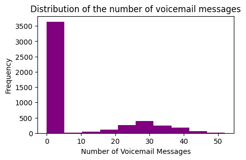

```python
import matplotlib.pyplot as plt

churndata['numbervmailmessages'].plot.hist(color='purple', figsize=(5, 3))
plt.xlabel('Number of Voicemail Messages')
plt.title('Distribution of the number of voicemail messages')
plt.show()
```

```python
count = (churndata['numbervmailmessages'] == 0).sum()
print('It is possible to conclude that', round(count/4950*100,2),'% of the observations are zero for the numbervmailmessages variable.')
```

```
It is possible to conclude that 73.54 % of the observations are zero for the numbervmailmessages variable.
```

The figure below showcases two separate bar graphs, delineating distinct variables. The left panel represents the quantity of customer service calls, while the right panel illustrates the count of international calls.

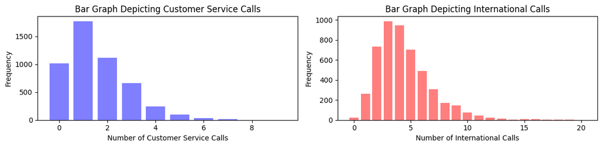

```python
import matplotlib.pyplot as plt

fig, axs = plt.subplots(1, 2, figsize=(12, 3))

number_service_calls = churndata['numbercustomerservicecalls'].sort_values().value_counts(sort=False)
axs[0].bar(number_service_calls.index, number_service_calls, color='blue', alpha=0.5)
axs[0].set_xlabel('Number of Customer Service Calls')
axs[0].set_ylabel('Frequency')
axs[0].set_title('Bar Graph Depicting Customer Service Calls')

total_intl_calls = churndata['totalintlcalls'].sort_values().value_counts(sort=False)
axs[1].bar(total_intl_calls.index, total_intl_calls, color='red', alpha=0.5)
axs[1].set_xlabel('Number of International Calls')
axs[1].set_ylabel('Frequency')
axs[1].set_title('Bar Graph Depicting International Calls')

plt.tight_layout()
plt.show()
```

As shown in the left panel above, the Customer Service Calls values have a range of 0 to 9. The value that occurs most frequently is 1. The right panel illustrates that the International Calls data have a minimum of 0 and a maximum of 20, half of the data are below or equal to 4 calls and the most frequently value is 3.

The following figure illustrates the distribution of three continuous variables: ‘accountlength’ in the first panel, ‘totalintlcharge’ in the second panel and ‘totalintlminutes’ in the third panel. The figure reveals that accountlength has a normal distribution. Additionally, totalintlcharge and totalintlminutes have distributions that are similar to a normal distribution, except for an unusual "peak" near zero.

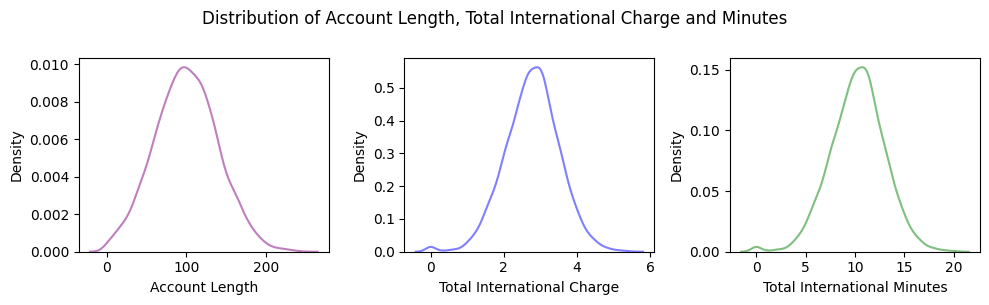

```python
import seaborn as sns
fig, axs = plt.subplots(1, 3, figsize=(10, 3))
sns.kdeplot(ax = axs[0], data=churndata, x='accountlength', alpha=0.5, color='purple', label='Account Length')
axs[0].set_xlabel('Account Length')
sns.kdeplot(ax = axs[1], data=churndata, x='totalintlcharge', alpha=0.5, color='blue', label='Total International Charge')
axs[1].set_xlabel('Total International Charge')
sns.kdeplot(ax = axs[2], data=churndata, x='totalintlminutes', alpha=0.5, color='green', label='Total International Minutes')
axs[2].set_xlabel('Total International Minutes')
plt.suptitle("Distribution of Account Length, Total International Charge and Minutes", x=0.5, y=1.0, ha='center')
plt.tight_layout()
plt.show()
```

The following graph depicts the distribution of three additional quantitative variables:‘totaldaycalls’, ‘totalevecalls’ and ‘totalnightcalls’. From the analysis of this graph, it is possible to conclude that the variables’ distributions exhibit a significant similarity to each other and they are approximately normal. This supports what was stated earlier in section 2.1, where it was specified that the 'totalevecalls' variable is not the result of adding the 'totaldaycalls' values and the 'totalnightcalls' values, but the number of calls in a different part of the day (evening). Based on the distributions, none of the variables matches the addition of the other two.

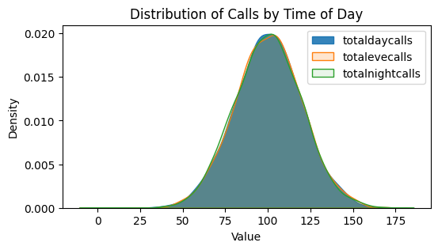

```python
plt.figure(figsize=(6,3))
sns.kdeplot(data=churndata, x='totaldaycalls', fill=True, alpha=0.9, label='totaldaycalls')
sns.kdeplot(data=churndata, x='totalevecalls', fill=True, alpha=0.2, label='totalevecalls')
sns.kdeplot(data=churndata, x='totalnightcalls', fill=True, alpha=0.1, label='totalnightcalls')
plt.title('Distribution of Calls by Time of Day')

plt.xlabel('Value')
plt.ylabel('Density')
plt.legend()
plt.show()
```

The following figure illustrates the distribution of the remaining six quantitative variables: 'totaldayminutes', 'totaleveminutes', 'totalnightminutes', 'totaldaycharge', 'totalevecharge' and 'totalnightcharge'.

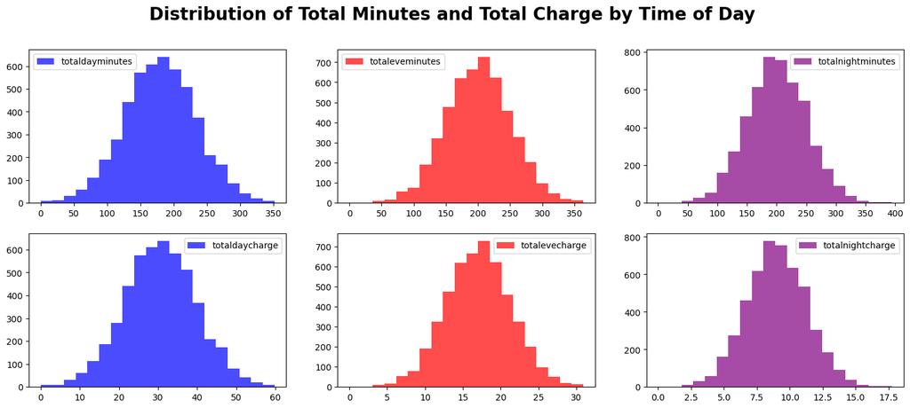

```python
fig, axs = plt.subplots(2, 3, figsize=(18, 7))

axs[0][0].hist(churndata['totaldayminutes'], bins=20, color='blue', alpha=0.7, label='totaldayminutes')
axs[0][0].legend()
axs[0][1].hist(churndata['totaleveminutes'], bins=20, color='red', alpha=0.7, label='totaleveminutes')
axs[0][1].legend()
axs[0][2].hist(churndata['totalnightminutes'], bins=20, color='purple', alpha=0.7, label='totalnightminutes')
axs[0][2].legend()
axs[1][0].hist(churndata['totaldaycharge'], bins=20, color='blue', alpha=0.7, label='totaldaycharge')
axs[1][0].legend()
axs[1][1].hist(churndata['totalevecharge'], bins=20, color='red', alpha=0.7, label='totalevecharge')
axs[1][1].legend()
axs[1][2].hist(churndata['totalnightcharge'], bins=20, color='purple', alpha=0.7, label='totalnightcharge')
axs[1][2].legend()
plt.suptitle('Distribution of Total Minutes and Total Charge by Time of Day', fontsize=20, color='black', fontweight='bold')
plt.show()
```

Based on the analysis of the figure above, the variables related to “minutes” have similar distributions. For the variables related to “charge”, the totalnightcharges tend to have lower values, while the totaldaycharges tend to have higher values.

#### Identifying outliers

The following three figures display the box plot for all numerical variables.

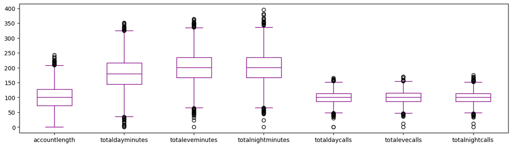

```python
churndata1 = churndata[["accountlength","totaldayminutes","totaleveminutes","totalnightminutes","totaldaycalls","totalevecalls","totalnightcalls"]]
churndata1.plot.box(color='purple',figsize=(15, 4))
```

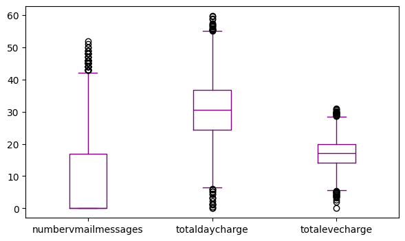

```python
churndata2 = churndata[["numbervmailmessages","totaldaycharge","totalevecharge"]]
churndata2.plot.box(color='purple',figsize=(7, 4))
```

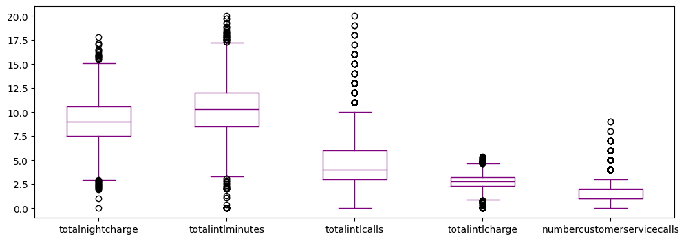

```python
churndata3 = churndata[["totalnightcharge","totalintlminutes","totalintlcalls","totalintlcharge","numbercustomerservicecalls"]]
churndata3.plot.box(color='purple',figsize=(12, 4))
```

Upon review of the boxplots above, all values are observed to fall within the acceptable ranges; consequently, it is determined that there is no necessity to address potential anomalies.

### 2.3 Bivariate Analysis

#### Graphical Display - Relationship between qualitative and quantitative variables

The following visualization illustrates number of calls stratified by classes and existence or nonexistence of specific plans. It analyzes customer service calls, voicemail messages, and international calls in relation to churn, voicemail plans, and international plans, respectively. Firstly, a large number of customer service calls may signify dissatisfaction, which could be a potential factor of churn. Secondly, the other goal is to ascertain whether the considerable frequency of zero values in ‘numbervmailmessages’ variable (as observed in section 2.2) corresponds with the absence of a voicemail plan among the clients.

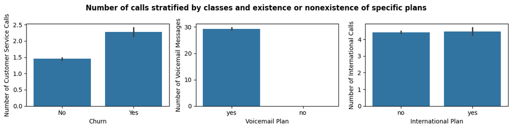

```python
fig, axs = plt.subplots(1, 3, figsize=(12, 3))

sns.barplot(data=churndata, x='churn', y='numbercustomerservicecalls', ax=axs[0])
axs[0].set_xlabel('Churn')
axs[0].set_ylabel('Number of Customer Service Calls')

sns.barplot(data=churndata, x='voicemailplan', y='numbervmailmessages', ax=axs[1])
axs[1].set_xlabel('Voicemail Plan')
axs[1].set_ylabel('Number of Voicemail Messages')

sns.barplot(data=churndata, x='internationalplan', y='totalintlcalls', ax=axs[2])
axs[2].set_xlabel('International Plan')
axs[2].set_ylabel('Number of International Calls')
plt.suptitle('Number of calls stratified by classes and existence or nonexistence of specific plans', fontsize=12, color='black', fontweight='bold')
plt.tight_layout()
plt.show()
```

```python
vmailmessages_yes_plan_zero = churndata[(churndata['voicemailplan'] == 'Yes') & (churndata['numbervmailmessages'] == 0)]
count1 = len(vmailmessages_yes_plan_zero)
vmailmessages_no_plan__dif_zero = churndata[(churndata['voicemailplan'] == 'No') & (churndata['numbervmailmessages'] != 0)]
count2 = len(vmailmessages_yes_plan_zero)
print("the number of observations with zero vmailmessages for clients with a voicemail plan is:", count1, "and the number of observations with >0 vmailmessages for clients without a voicemail plan is:", count2)
```

```
the number of observations with zero vmailmessages for clients with a voicemail plan is: 0 and the number of observations with >0 vmailmessages for clients without a voicemail plan is: 0
```

Regarding the first panel, it can be concluded that the “yes_churn” class has a higher average number of service calls. The averages for each case are verified below.

```python
from statistics import *
import pandas as pd
import numpy as np

servicecalls_no_churn = churndata['numbercustomerservicecalls'].loc[churndata['churn']=='No']
servicecalls_yes_churn = churndata['numbercustomerservicecalls'].loc[churndata['churn']=='Yes']

servicecalls_no_churn_numeric = pd.to_numeric(servicecalls_no_churn, errors='coerce')
servicecalls_yes_churn_numeric = pd.to_numeric(servicecalls_yes_churn, errors='coerce')

mean_value1 = np.nanmean(servicecalls_no_churn_numeric)
mean_value2 = np.nanmean(servicecalls_yes_churn_numeric)

print("mean of servicecalls_no_churn:", round(mean_value1,2), "and mean of servicecalls_yes_churn:", round(mean_value2,2))
```

```
mean of servicecalls_no_churn: 1.45 and mean of servicecalls_yes_churn: 2.27
```

From the analysis of the bar plot below, it can be conclude that following the 4 number of service calls, there are no additional instances of customers categorized as “no_churn”. This suggests that this variable can be a predictor of churn.

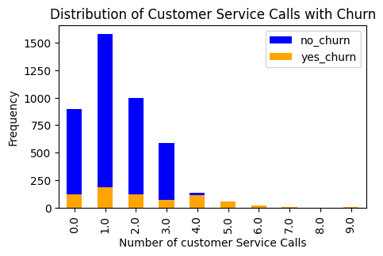

```python
import matplotlib.pyplot as plt
plt.figure(figsize=(5, 3))
servicecalls_no_churn.sort_values().value_counts(sort=False).plot.bar(color='blue')
servicecalls_yes_churn.sort_values().value_counts(sort=False).plot.bar(color='orange')
plt.legend(labels=['no_churn','yes_churn'])

plt.title('Distribution of Customer Service Calls with Churn')
plt.xlabel('Number of customer Service Calls')
plt.ylabel('Frequency')
```

The Account length variable can also be an important factor in churn analysis as it could reflect the customer’s loyalty. Customers who have been with a company for a longer period may be less likely to churn. However, the relationship between account length and churn is not clear-cut and can vary depending on other factors such as the quality of service, customer satisfaction, and competitive offers.

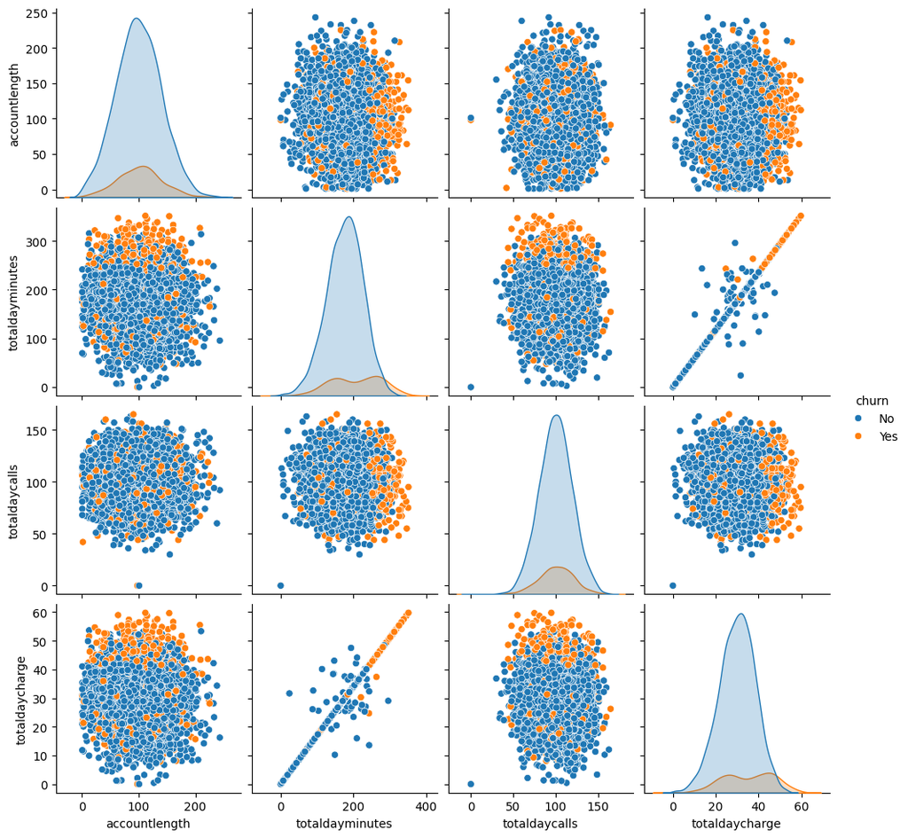

```python
churndata4 = churndata[["churn","accountlength","totaldayminutes","totaldaycalls","totaldaycharge"]]
import seaborn as sns
sns.pairplot(churndata4, hue="churn", height=2.5)
plt.show()
```

Finally, an attempt was made to create a 3D visualization with different variables, but no extraordinary pattern was found.

#### Correlation Matrix

Before building the correlation matrix, the variables “churn”, “internationalplan”, “voicemailplan” were transformed into binary format:

- "churn": Indicates whether the customer left the service (1 if yes, 0 if no);
- "internationalplan": Indicates whether the customer has an international plan, with calls and messages to other countries (1 if yes, 0 if no);
- "voicemailplan": Indicates whether the customer has a voicemail plan (1 if yes, 0 if no).

```python
churndataY = churndata
churndataY['churn'] = churndataY['churn'].map({'Yes': 1, 'No': 0})
churndataY['internationalplan'] = churndataY['internationalplan'].map({'yes': 1, 'no': 0})
churndataY['voicemailplan'] = churndataY['voicemailplan'].map({'yes': 1, 'no': 0})
```

The following table shows the pairwise correlation coefficients between the variables in the dataframe.

```python
churndataY.corr()
```

|  | churn | accountlength | internationalplan | voicemailplan | numbervmailmessages | totaldayminutes | totaldaycalls | totaldaycharge | totaleveminutes | totalevecalls | totalevecharge | totalnightminutes | totalnightcalls | totalnightcharge | totalintlminutes | totalintlcalls | totalintlcharge | numbercustomerservicecalls |
| --- | --- | --- | --- | --- | --- | --- | --- | --- | --- | --- | --- | --- | --- | --- | --- | --- | --- | --- |
| churn | 1.000000 | 0.018030 | 0.257739 | -0.109166 | -0.100033 | 0.203456 | 0.015843 | 0.203629 | 0.089648 | -0.008123 | 0.089903 | 0.043556 | -0.006869 | 0.046459 | 0.062206 | -0.045500 | 0.061505 | 0.218272 |
| accountlength | 0.018030 | 1.000000 | 0.009300 | -0.008369 | -0.016578 | -0.002032 | 0.026608 | 0.000848 | -0.008350 | 0.010261 | -0.006566 | 0.003416 | -0.013918 | 0.002029 | 0.000179 | 0.013805 | -0.002017 | -0.001163 |
| internationalplan | 0.257739 | 0.009300 | 1.000000 | 0.008458 | 0.012478 | 0.025765 | 0.007711 | 0.024802 | 0.020192 | 0.000844 | 0.020056 | -0.025526 | 0.004934 | -0.025698 | 0.029532 | 0.006687 | 0.029567 | -0.011273 |
| voicemailplan | -0.109166 | -0.008369 | 0.008458 | 1.000000 | 0.954345 | 0.005343 | 0.000262 | 0.005500 | 0.025624 | -0.004908 | 0.025560 | 0.007401 | 0.006825 | 0.007514 | 0.003239 | -0.008195 | 0.004696 | -0.013411 |
| numbervmailmessages | -0.100033 | -0.016578 | 0.012478 | 0.954345 | 1.000000 | 0.008372 | 0.001462 | 0.008061 | 0.021511 | -0.006178 | 0.021395 | 0.004602 | 0.001303 | 0.005013 | 0.004232 | -0.005106 | 0.004376 | -0.009822 |
| totaldayminutes | 0.203456 | -0.002032 | 0.025765 | 0.005343 | 0.008372 | 1.000000 | 0.003293 | 0.992380 | -0.012065 | 0.008590 | -0.012963 | 0.009139 | 0.004781 | 0.008854 | -0.021166 | 0.001703 | -0.019034 | -0.005587 |
| totaldaycalls | 0.015843 | 0.026608 | 0.007711 | 0.000262 | 0.001462 | 0.003293 | 1.000000 | -0.000558 | -0.001513 | 0.002660 | -0.000358 | 0.005791 | -0.006968 | 0.003363 | 0.015901 | 0.011160 | 0.013841 | -0.009722 |
| totaldaycharge | 0.203629 | 0.000848 | 0.024802 | 0.005500 | 0.008061 | 0.992380 | -0.000558 | 1.000000 | -0.007493 | 0.009208 | -0.007804 | 0.009312 | 0.003755 | 0.009024 | -0.021769 | 0.001052 | -0.018907 | -0.003352 |
| totaleveminutes | 0.089648 | -0.008350 | 0.020192 | 0.025624 | 0.021511 | -0.012065 | -0.001513 | -0.007493 | 1.000000 | 0.004650 | 1.000000 | -0.018643 | 0.013485 | -0.017422 | 0.000448 | 0.011040 | -0.005342 | -0.013153 |
| totalevecalls | -0.008123 | 0.010261 | 0.000844 | -0.004908 | -0.006178 | 0.008590 | 0.002660 | 0.009208 | 0.004650 | 1.000000 | 0.004467 | 0.003123 | -0.013249 | 0.003388 | -0.006909 | 0.001281 | -0.005569 | 0.005610 |
| totalevecharge | 0.089903 | -0.006566 | 0.020056 | 0.025560 | 0.021395 | -0.012963 | -0.000358 | -0.007804 | 1.000000 | 0.004467 | 1.000000 | -0.017154 | 0.013523 | -0.015944 | 0.001506 | 0.009793 | -0.004307 | -0.011596 |
| totalnightminutes | 0.043556 | 0.003416 | -0.025526 | 0.007401 | 0.004602 | 0.009139 | 0.005791 | 0.009312 | -0.018643 | 0.003123 | -0.017154 | 1.000000 | 0.024878 | 0.999999 | -0.006868 | -0.018524 | -0.006458 | -0.006074 |
| totalnightcalls | -0.006869 | -0.013918 | 0.004934 | 0.006825 | 0.001303 | 0.004781 | -0.006968 | 0.003755 | 0.013485 | -0.013249 | 0.013523 | 0.024878 | 1.000000 | 0.028675 | -0.000226 | -0.001015 | 0.004183 | -0.007087 |
| totalnightcharge | 0.046459 | 0.002029 | -0.025698 | 0.007514 | 0.005013 | 0.008854 | 0.003363 | 0.009024 | -0.017422 | 0.003388 | -0.015944 | 0.999999 | 0.028675 | 1.000000 | -0.007925 | -0.016420 | -0.007451 | -0.004917 |
| totalintlminutes | 0.062206 | 0.000179 | 0.029532 | 0.003239 | 0.004232 | -0.021166 | 0.015901 | -0.021769 | 0.000448 | -0.006909 | 0.001506 | -0.006868 | -0.000226 | -0.007925 | 1.000000 | 0.018186 | 0.994521 | -0.010933 |
| totalintlcalls | -0.045500 | 0.013805 | 0.006687 | -0.008195 | -0.005106 | 0.001703 | 0.011160 | 0.001052 | 0.011040 | 0.001281 | 0.009793 | -0.018524 | -0.001015 | -0.016420 | 0.018186 | 1.000000 | 0.022057 | -0.019813 |
| totalintlcharge | 0.061505 | -0.002017 | 0.029567 | 0.004696 | 0.004376 | -0.019034 | 0.013841 | -0.018907 | -0.005342 | -0.005569 | -0.004307 | -0.006458 | 0.004183 | -0.007451 | 0.994521 | 0.022057 | 1.000000 | -0.011587 |
| numbercustomerservicecalls | 0.218272 | -0.001163 | -0.011273 | -0.013411 | -0.009822 | -0.005587 | -0.009722 | -0.003352 | -0.013153 | 0.005610 | -0.011596 | -0.006074 | -0.007087 | -0.004917 | -0.010933 | -0.019813 | -0.011587 | 1.000000 |

Given that the majority of the quantitative variables exhibit a distribution that approximates normality, and considering that the binary variable is coded as 0 and 1, the application of Pearson’s correlation coefficient yielded an outcome that is similar to the point-biserial correlation coefficient.

Based on the analysis of the preceding table, the features that show a relatively higher degree of correlation with “churn” are: “internationalplan”, “totaldayminutes”, “totaldaycharge”, and “numbercustomerservicecalls”. These features have a correlation coefficient of around 0.20, which is usually regarded as a low to medium correlation.

Finally, the following pairs of features have a very high positive correlation:

- "totaldayminutes" and "totaldaycharge" (correlation coefficient of approximately 0.99);
- "totaleveminutes" and "totalevecharge" (correlation coefficient of 1.00);
- "totalnightminutes" and "totalnightcharge" (correlation coefficient of approximately 1.00);
- "totalintlminutes" and "totalintlcharge" (correlation coefficient of approximately 0.99);
- "voicemailplan" and "numbervmailmessages" (correlation coefficient of approximately 0.95). A strong relationship between these variables was observed in the graph “Number of vmailmessages stratified by existence or nonexistence of a voicemail plan” at the start of section 2.3.

### 2.4 Brief summary

The data is imbalanced, as shown by the fact that the minority class, which corresponds to the customers who have churned, accounts for 14 % of the total. Improper administration of this will lead to a model that is biased towards the majority class. In addition, as observed in the beggining of this section, the data is incomplete. Hence, these issues need to be addressed in section 3.

Finally, in section 3, the redundant variables will be removed.

## 3 | Data Preparation

### 3.1 Data Cleaning

#### Removing Redundant Variables

First, as previously stated, the redundant variables were removed. All "charge" variables were removed, due to the strong correlation they exhibited with their corresponding “minutes” variables. The selection of variables to be removed from these highly correlated pairs was arbitrary, since they had the same percentage of missing values. The "numbervmailmessages" variables was also removed, due to the strong correlation with "voicemailplan" and its zero values indicated the absence of a voicemail plan, as seen at the start of section 2.3.

```python
churndata_dc=churndataY
```

```python
columns_drop=['totaldaycharge','totalevecharge','totalnightcharge','totalintlcharge']
churndata_dc.drop(columns_drop, axis=1, inplace=True)
```

```python
columns_drop=['numbervmailmessages']
churndata_dc.drop(columns_drop, axis=1, inplace=True)
```

#### Handling Missing Data

As shown in section 2.1, the variable accountlength had the second-lowest proportion of null values after the variable churn. Based on this criterion, the dataset was filtered by excluding all observations with missing values in the variable accountlength.

```python
churndata_dc = churndata_dc.dropna(subset=['accountlength'])
churndata_dc.info()
```

```
<class 'pandas.core.frame.DataFrame'>
Index: 4951 entries, 0 to 4999
Data columns (total 13 columns):
 #   Column                      Non-Null Count  Dtype
---  ------                      --------------  -----
 0   churn                       4951 non-null   int64
 1   accountlength               4951 non-null   float64
 2   internationalplan           4902 non-null   float64
 3   voicemailplan               4902 non-null   float64
 4   totaldayminutes             4902 non-null   float64
 5   totaldaycalls               4901 non-null   float64
 6   totaleveminutes             4902 non-null   float64
 7   totalevecalls               4901 non-null   float64
 8   totalnightminutes           4901 non-null   float64
 9   totalnightcalls             4901 non-null   float64
 10  totalintlminutes            4903 non-null   float64
 11  totalintlcalls              4901 non-null   float64
 12  numbercustomerservicecalls  4901 non-null   float64
dtypes: float64(12), int64(1)
memory usage: 541.5 KB
```

For the remaining variables, the missing values were imputed by applying the KNNImputer algorithm with a parameter of k=5, thus obtaining a complete dataset. Thus, the final dataset contains 4951 observations (49 less than the original).

```python
from sklearn.impute import KNNImputer
columns_to_impute = ['voicemailplan', 'internationalplan', 'totaldayminutes', 'totaldaycalls','totaleveminutes',
                    'totalevecalls','totalnightminutes','totalnightcalls','totalintlminutes','totalintlcalls','numbercustomerservicecalls']
imputer=KNNImputer(n_neighbors=5)
churndata_dc[columns_to_impute] = imputer.fit_transform(churndata_dc[columns_to_impute])
churndata_dc.info()
```

```
<class 'pandas.core.frame.DataFrame'>
Index: 4951 entries, 0 to 4999
Data columns (total 13 columns):
 #   Column                      Non-Null Count  Dtype
---  ------                      --------------  -----
 0   churn                       4951 non-null   int64
 1   accountlength               4951 non-null   float64
 2   internationalplan           4951 non-null   float64
 3   voicemailplan               4951 non-null   float64
 4   totaldayminutes             4951 non-null   float64
 5   totaldaycalls               4951 non-null   float64
 6   totaleveminutes             4951 non-null   float64
 7   totalevecalls               4951 non-null   float64
 8   totalnightminutes           4951 non-null   float64
 9   totalnightcalls             4951 non-null   float64
 10  totalintlminutes            4951 non-null   float64
 11  totalintlcalls              4951 non-null   float64
 12  numbercustomerservicecalls  4951 non-null   float64
dtypes: float64(12), int64(1)
memory usage: 541.5 KB
```

A subsequent analysis of the data below revealed that the imputation process transformed some binary variables into quantitative, so we have to reverse this. Besides that, the values of the other variables fall within reasonable ranges, having no wrong values. Based on this criterion and the previous analysis of outliers in chapter 2, no observations were excluded at this stage.

```python
churndata_dc.apply(min, axis=0)
```

```
churn                         0.0
accountlength                 1.0
internationalplan             0.0
voicemailplan                 0.0
totaldayminutes               0.0
totaldaycalls                 0.0
totaleveminutes               0.0
totalevecalls                 0.0
totalnightminutes             0.0
totalnightcalls               0.0
totalintlminutes              0.0
totalintlcalls                0.0
numbercustomerservicecalls    0.0
dtype: float64
```

```python
churndata_dc.apply(max, axis=0)
```

```
churn                           1.0
accountlength                 243.0
internationalplan               1.0
voicemailplan                   1.0
totaldayminutes               351.5
totaldaycalls                 165.0
totaleveminutes               363.7
totalevecalls                 170.0
totalnightminutes             395.0
totalnightcalls               175.0
totalintlminutes               20.0
totalintlcalls                 20.0
numbercustomerservicecalls      9.0
dtype: float64
```

```python
unique_values = churndata_dc[['internationalplan','voicemailplan','churn']].apply(lambda x: x.unique())
print(unique_values)
```

```
internationalplan         [0.0, 1.0, 0.2, 0.4, 0.6]
voicemailplan        [1.0, 0.0, 0.2, 0.6, 0.4, 0.8]
churn                                        [0, 1]
dtype: object
```

```python
churndata_dc['voicemailplan'] = churndata_dc['voicemailplan'].apply(lambda x: 0 if x < 0.5 else 1)
churndata_dc['voicemailplan'].unique()
```

```
array([1, 0])
```

```python
churndata_dc['internationalplan'] = churndata_dc['internationalplan'].apply(lambda x: 0 if x < 0.5 else 1)
churndata_dc['internationalplan'].unique()
```

```
array([0, 1])
```

After eliminating the redundant variables and handling the missing data, a new correlation matrix was constructed, which did not reveal any exceptionally high correlations (see below).

```python
churndata_dc.corr()
```

|  | churn | accountlength | internationalplan | voicemailplan | totaldayminutes | totaldaycalls | totaleveminutes | totalevecalls | totalnightminutes | totalnightcalls | totalintlminutes | totalintlcalls | numbercustomerservicecalls |
| --- | --- | --- | --- | --- | --- | --- | --- | --- | --- | --- | --- | --- | --- |
| churn | 1.000000 | 0.018030 | 0.256329 | -0.109041 | 0.201131 | 0.016108 | 0.089859 | -0.007995 | 0.040759 | -0.010416 | 0.060173 | -0.045746 | 0.215305 |
| accountlength | 0.018030 | 1.000000 | 0.009440 | -0.006240 | -0.001013 | 0.026338 | -0.007811 | 0.010478 | 0.002678 | -0.013662 | 0.000025 | 0.013764 | -0.001611 |
| internationalplan | 0.256329 | 0.009440 | 1.000000 | 0.009237 | 0.023466 | 0.008768 | 0.018863 | 0.000254 | -0.028921 | 0.002973 | 0.030583 | 0.006472 | -0.010636 |
| voicemailplan | -0.109041 | -0.006240 | 0.009237 | 1.000000 | 0.006992 | 0.000576 | 0.023408 | -0.006066 | 0.011134 | 0.003408 | 0.000762 | -0.009610 | -0.015792 |
| totaldayminutes | 0.201131 | -0.001013 | 0.023466 | 0.006992 | 1.000000 | 0.003086 | -0.009178 | 0.010249 | 0.008101 | 0.002875 | -0.021725 | -0.000341 | -0.003597 |
| totaldaycalls | 0.016108 | 0.026338 | 0.008768 | 0.000576 | 0.003086 | 1.000000 | -0.000081 | 0.003769 | 0.005883 | -0.008442 | 0.013001 | 0.010247 | -0.009632 |
| totaleveminutes | 0.089859 | -0.007811 | 0.018863 | 0.023408 | -0.009178 | -0.000081 | 1.000000 | 0.002095 | -0.015467 | 0.015167 | 0.000629 | 0.008670 | -0.013558 |
| totalevecalls | -0.007995 | 0.010478 | 0.000254 | -0.006066 | 0.010249 | 0.003769 | 0.002095 | 1.000000 | 0.005425 | -0.014053 | -0.009459 | 0.002629 | 0.006558 |
| totalnightminutes | 0.040759 | 0.002678 | -0.028921 | 0.011134 | 0.008101 | 0.005883 | -0.015467 | 0.005425 | 1.000000 | 0.022244 | -0.007165 | -0.017940 | -0.005399 |
| totalnightcalls | -0.010416 | -0.013662 | 0.002973 | 0.003408 | 0.002875 | -0.008442 | 0.015167 | -0.014053 | 0.022244 | 1.000000 | -0.001612 | -0.002239 | -0.006451 |
| totalintlminutes | 0.060173 | 0.000025 | 0.030583 | 0.000762 | -0.021725 | 0.013001 | 0.000629 | -0.009459 | -0.007165 | -0.001612 | 1.000000 | 0.020623 | -0.011619 |
| totalintlcalls | -0.045746 | 0.013764 | 0.006472 | -0.009610 | -0.000341 | 0.010247 | 0.008670 | 0.002629 | -0.017940 | -0.002239 | 0.020623 | 1.000000 | -0.018888 |
| numbercustomerservicecalls | 0.215305 | -0.001611 | -0.010636 | -0.015792 | -0.003597 | -0.009632 | -0.013558 | 0.006558 | -0.005399 | -0.006451 | -0.011619 | -0.018888 | 1.000000 |

### 3.2 Feature Selecting

The selected predictors are: 'accountlength', 'internationalplan', 'voicemailplan', 'totaldayminutes', 'totaldaycalls', 'totaleveminutes', 'totalevecalls', 'totalnightminutes', 'totalnightcalls', 'totalintlminutes', 'totalintlcalls' and 'numbercustomerservicecalls'. Among these, the features 'internationalplan', 'totaldayminutes' and 'numbercustomerservicecalls' exhibit a comparatively stronger correlation with churn.

## 4 | Modelling

As a preliminary step, the data was standardized to enhance the performance of certain models, such as logistic regression and neural network.

```python
from sklearn.preprocessing import StandardScaler

columns_to_standardize = ['accountlength', 'totaldayminutes', 'totaldaycalls', 'totaleveminutes',
                          'totalevecalls', 'totalnightminutes', 'totalnightcalls',
                          'totalintlminutes', 'totalintlcalls', 'numbercustomerservicecalls']

scaler = StandardScaler()
churndata_dc[columns_to_standardize] = scaler.fit_transform(churndata_dc[columns_to_standardize])
```

```python
import numpy as np
import statsmodels.api as sm
from sklearn.linear_model import LogisticRegression
from scipy.stats import logistic
from sklearn.svm import SVC
from sklearn.metrics import accuracy_score, recall_score, precision_score, f1_score, log_loss, precision_recall_curve, roc_auc_score, roc_curve, auc
from sklearn.model_selection import train_test_split
from sklearn.model_selection import cross_val_score, KFold
from sklearn.model_selection import cross_validate
import matplotlib.pyplot as plt
from sklearn.metrics import confusion_matrix,ConfusionMatrixDisplay

ch=churndata_dc
x = ch.loc[:, ~ch.columns.isin(['churn'])]
y = ch.loc[:,'churn']

x_train, x_test, y_train, y_test = train_test_split(x, y, test_size=0.2, random_state=42, shuffle=True, stratify=y)
```

### 4.1 Balanced Data

The problem of data imbalance was addressed by applying undersampling, which reduced the number of instances in the majority class (‘not churn’) to equal the number of instances in the minority class (‘churn’) in the training set. This involved a random selection of a subset of examples from the majority class.

Nevertheless, the estimate of future prediction error will be obtained with the original distribution and without data leakage.

```python
from imblearn.under_sampling import RandomUnderSampler

under_sampler = RandomUnderSampler(random_state=42)

x_trainb, y_trainb = under_sampler.fit_resample(x_train, y_train)
```

It is noteworthy that the training set contains less than 30 % of the instances from the original training set, which could impact the variability of the results when performing cross-validation, due to the smaller data size.

#### 4.1.1 Logistic Regression

In scikit-learn, the default values for the logistic regression are: **C**=1.0, **penalty**=‘l2’, **solver**=‘lbfgs’, **class_weight**=None, **dual**=False, **tol**=0.0001, **fit_intercept**=True, **intercept_scaling**=1, **random_state**=None, **max_iter**=100, **multi_class**=‘auto’, **verbose**=0, **warm_start**=False, **n_jobs**=None, **l1_ratio**=None. The parameter **class_weight**='balanced' was employed in this section.

Cross-validation was initially applied, as shown below, to determine the optimal parameters. After conducting several experiments, the parameters C=1.0, penalty='l1', and solver='liblinear' were found to be optimal. For the remaining parameters, the default values were used during the experiments.

```python
def LogReg_balanced_CV(x, y, C=1.0, penalty='l1',solver='liblinear'):

    LogReg = LogisticRegression(C=C, penalty=penalty, solver=solver, class_weight='balanced', dual=False, fit_intercept=True,
                                intercept_scaling=1, max_iter=100, multi_class='ovr', n_jobs=1,
                                tol=0.0001)

    scoring = ['accuracy', 'recall', 'precision', 'f1']

    scores = cross_validate(LogReg, x_trainb, y_trainb, cv=5, scoring=scoring)

    print("Average Scores and Standard Deviation:")

    for name in scoring:
      score_values = scores['test_' + name]
      score_mean = np.mean(score_values)
      score_std = np.std(score_values)
      print("%0.3f %s with a standard deviation of %0.3f" % (score_mean, name, score_std))

LogReg_balanced_CV(x, y, C=1.0, penalty='l1',solver='liblinear')
```

```
Average Scores and Standard Deviation:
0.762 accuracy with a standard deviation of 0.031
0.766 recall with a standard deviation of 0.066
0.763 precision with a standard deviation of 0.037
0.762 f1 with a standard deviation of 0.037
```

Below, the Coefficients, pseudo R square, and scores for the testing set are presented, using the optimal parameters of the logistic regression and using x_test and y_test to make predictions and evaluate the model.

```
                            Coefficients (betas)
accountlength                              0.094
internationalplan                          2.181
voicemailplan                             -0.695
totaldayminutes                            0.682
totaldaycalls                              0.034
totaleveminutes                            0.379
totalevecalls                             -0.013
totalnightminutes                          0.210
totalnightcalls                           -0.125
totalintlminutes                           0.172
totalintlcalls                            -0.172
numbercustomerservicecalls                 0.810
Model intercept: [-0.576]
Pseudo R square: 0.227


Scores for the testing set:
Accuracy score: 0.754
Recall score for the positive class: 0.75
Precision score for the positive class: 0.334
F1 score for the positive class: 0.463

AUPRC & AUROC:
Area under the precision-recall curve: 0.44
Area under the ROC curve: 0.818

Confusion Matrix:
```

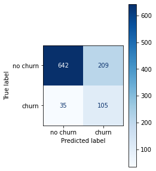

```python
def LogReg_balanced(x, y, C=1.0, penalty='l1',solver='liblinear'):

    LogReg = LogisticRegression(C=C, penalty=penalty, solver=solver, class_weight='balanced', dual=False, fit_intercept=True,
                                intercept_scaling=1, max_iter=100, multi_class='ovr', n_jobs=1,
                                tol=0.0001)

    LogReg.fit(x_trainb, y_trainb)
    y_pred = LogReg.predict(x_test)

    coef_df = pd.DataFrame(np.round(LogReg.coef_, 3), columns=x.columns)
    coef_df_transposed = coef_df.transpose()
    coef_df_transposed.columns = ['Coefficients (betas)']

    print(coef_df_transposed)
    print("Model intercept:", np.round(LogReg.intercept_, 3))

    nll_model = log_loss(y_test, LogReg.predict_proba(x_test))
    nll_null = log_loss(y_test, np.repeat(y_trainb.mean(), len(y_test)))
    pseudo_r2 = 1 - (nll_model / nll_null)
    print('Pseudo R square:', np.round(pseudo_r2, 3))

    cm = confusion_matrix(y_test, y_pred)
    labels = ['no churn', 'churn']
    cm_display = ConfusionMatrixDisplay(cm, display_labels=labels)

    pos_class = 1

    accuracy = accuracy_score(y_test, y_pred)
    recall = recall_score(y_test, y_pred, pos_label=pos_class)
    precision = precision_score(y_test, y_pred, pos_label=pos_class)
    f1score = f1_score(y_test, y_pred, pos_label=pos_class)
    print("")
    print("")
    print("Scores for the testing set:")
    print('Accuracy score:', np.round(accuracy, 3))
    print('Recall score for the positive class:', np.round(recall, 3))
    print('Precision score for the positive class:', np.round(precision, 3))
    print('F1 score for the positive class:', np.round(f1score, 3))

    y_pred_1 = LogReg.predict_proba(x_test)[:, 1]
    precision, recall, _ = precision_recall_curve(y_test, y_pred_1)
    fpr, tpr, _ = roc_curve(y_test, y_pred_1)
    print("")
    print("AUPRC & AUROC:")
    print('Area under the precision-recall curve:', np.round(auc(recall, precision),3))
    print('Area under the ROC curve:', np.round(auc(fpr, tpr),3))
    print("")
    print('Confusion Matrix: ')
    fig, ax = plt.subplots(figsize=(3,5))
    cm_display.plot(ax=ax, cmap='Blues')

LogReg_balanced(x, y, C=1.0, penalty='l1',solver='liblinear')
```

To improve the performance of the logistic regression model, the threshold was adjusted to optimize the F1 score for the positive class in the testing set. The threshold is not a parameter of the model, but a decision rule that can be applied to the predicted probabilities to assign labels. The default threshold is 0.5, which means that the model predicts the positive class if the probability of the positive class is greater than 0.5. To use a different threshold value, the probability estimates were obtained using the predict_proba method, as shown in the code below. Important note: The threshold does not affect the estimation of the coefficients, but it affects the evaluation of the model’s performance on the test data.

```python
def optimalt_LogReg_balanced(x, y, C=1.0, penalty='l1',solver='liblinear'):

    LogReg = LogisticRegression(C=C, penalty=penalty, solver=solver, class_weight='balanced', dual=False, fit_intercept=True,
                                intercept_scaling=1, max_iter=100, multi_class='ovr', n_jobs=1,
                                tol=0.0001)

    LogReg.fit(x_trainb, y_trainb)

    y_pred_1 = LogReg.predict_proba(x_test)[:, 1]

    f1_scores = [f1_score(y_test, y_pred_1 > t) for t in np.linspace(0, 1, 101)]
    best_threshold = np.linspace(0, 1, 101)[np.argmax(f1_scores)]

    print('Optimal threshold that maximizes the F1 score:', np.round(best_threshold,3))

optimalt_LogReg_balanced(x, y, C=1.0, penalty='l1',solver='liblinear')
```

```
Optimal threshold that maximizes the F1 score: 0.62
```

```python
def LogReg_balanced_withthreshold(x, y, C=1.0, threshold= 0.62, penalty='l1',solver='liblinear'):

    LogReg = LogisticRegression(C=C, penalty=penalty, solver=solver, class_weight='balanced', dual=False, fit_intercept=True,
                                intercept_scaling=1, max_iter=100, multi_class='ovr', n_jobs=1,
                                tol=0.0001)

    LogReg.fit(x_trainb, y_trainb)

    proba = LogReg.predict_proba(x_test)[:, 1]
    y_pred = np.where(proba > threshold, 1, 0)

    pos_class = 1

    accuracy = accuracy_score(y_test, y_pred)
    recall = recall_score(y_test, y_pred, pos_label=pos_class)
    precision = precision_score(y_test, y_pred, pos_label=pos_class)
    f1score = f1_score(y_test, y_pred, pos_label=pos_class)
    print('Accuracy score:', np.round(accuracy, 3))
    print('Recall score for the positive class:', np.round(recall, 3))
    print('Precision score for the positive class:', np.round(precision, 3))
    print('F1 score for the positive class:', np.round(f1score, 3))

print("Scores with the default threshold:")
LogReg_balanced_withthreshold(x, y, C=1.0, threshold= 0.5, penalty='l1',solver='liblinear')
print("")
print("Scores with the optimal threshold:")
LogReg_balanced_withthreshold(x, y, C=1.0, threshold= 0.62, penalty='l1',solver='liblinear')
```

```
Scores with the default threshold:
Accuracy score: 0.754
Recall score for the positive class: 0.75
Precision score for the positive class: 0.334
F1 score for the positive class: 0.463

Scores with the optimal threshold:
Accuracy score: 0.824
Recall score for the positive class: 0.636
Precision score for the positive class: 0.42
F1 score for the positive class: 0.506
```

The optimal threshold yields better results for the accuracy, precision, and f1 score than the default threshold, but the precision and f1 scores remain low.

Reference: https://scikit-learn.org/stable/supervised_learning.html

#### 4.1.2 KNN

```python
from sklearn.neighbors import KNeighborsClassifier
from sklearn import neighbors
from sklearn.model_selection import GridSearchCV
params = {'n_neighbors':[2,3,4,5,6,7,8,9]}
knn = neighbors.KNeighborsRegressor()
knn_model = GridSearchCV(knn, params, cv=5)
knn_model.fit(x_trainb,y_trainb)
knn_model.best_params_
```

```
{'n_neighbors': 7}
```

```python
knn_modelb=neighbors.KNeighborsRegressor(n_neighbors = 7)
knn_modelb.fit(x_trainb,y_trainb)
```

```
KNeighborsRegressor(n_neighbors=7)
```

```python
#Cross Validation
KNNClassifier = KNeighborsClassifier(n_neighbors=7)
scoring = ['accuracy', 'recall', 'precision', 'f1']
scores = cross_validate(KNNClassifier, x_trainb, y_trainb, cv=5, scoring=scoring)

print("Average Scores and Standard Deviation:")
for name in scoring:
    score_values = scores['test_' + name][2:]
    score_mean = np.mean(score_values)
    score_std = np.std(score_values)
    print("%0.3f %s with a standard deviation of %0.3f" % (score_mean, name, score_std))
```

```
Average Scores and Standard Deviation:
0.777 accuracy with a standard deviation of 0.020
0.705 recall with a standard deviation of 0.041
0.824 precision with a standard deviation of 0.026
0.759 f1 with a standard deviation of 0.026
```

```
Scores for the testing set:
Accuracy score: 0.801
Recall score for the positive class: 0.693
Precision score for the positive class: 0.386
F1 score for the positive class: 0.496

Confusion Matrix:
```

```
<sklearn.metrics._plot.confusion_matrix.ConfusionMatrixDisplay at 0x7fcce240b910>
```

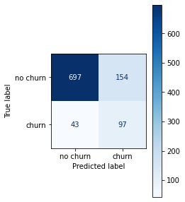

```python
# TRAINING SET
KNNClassifier.fit(x_trainb, y_trainb)
y_pred = KNNClassifier.predict(x_test)

cm = confusion_matrix(y_test, y_pred)
labels = ['no churn', 'churn']
cm_display = ConfusionMatrixDisplay(cm, display_labels=labels)

pos_class = 1

accuracy = accuracy_score(y_test, y_pred)
recall = recall_score(y_test, y_pred, pos_label=pos_class)
precision = precision_score(y_test, y_pred, pos_label=pos_class)
f1score = f1_score(y_test, y_pred, pos_label=pos_class)
print("")
print("")
print("Scores for the testing set:")
print('Accuracy score:', np.round(accuracy, 3))
print('Recall score for the positive class:', np.round(recall, 3))
print('Precision score for the positive class:', np.round(precision, 3))
print('F1 score for the positive class:', np.round(f1score, 3))
print("")
print('Confusion Matrix: ')
fig, ax = plt.subplots(figsize=(3,5))
cm_display.plot(ax=ax, cmap='Blues')
```

Comparing the scores obtained in both cases it is obvious the diference with the values, especially in the precision domain that dropped a lot. This could be related to the imbalanced test set or to the division and balancing of the dataset.

With such a contradiction between tests, but assuming the multiple tests of the cross-validation method have more weight, it can be concluded that this model, despite being easy to implement, can achieve good results, but still has room to improvement.

To improve the performance of the model, the threshold was adjujsted to maximize the F1 score, as was done before.

```python
# OPTIMAL THRESHOLD
KNNClassifier = KNeighborsClassifier(n_neighbors=7)
KNNClassifier.fit(x_trainb, y_trainb)

y_pred_1 = KNNClassifier.predict_proba(x_test)[:, 1]

f1_scores = [f1_score(y_test, y_pred_1 > t) for t in np.linspace(0, 1, 101)]
best_threshold = np.linspace(0, 1, 101)[np.argmax(f1_scores)]

print('Optimal threshold that maximizes the F1 score:', np.round(best_threshold,3))
```

```
Optimal threshold that maximizes the F1 score: 0.58
```

```python
KNNClassifier = KNeighborsClassifier(n_neighbors=7)
KNNClassifier.fit(x_trainb, y_trainb)

proba =KNNClassifier.predict_proba(x_test)[:, 1]

pos_class = 1

y_pred = np.where(proba > 0.5, 1, 0)
print("Scores with the default threshold:")
accuracy = accuracy_score(y_test, y_pred)
recall = recall_score(y_test, y_pred, pos_label=pos_class)
precision = precision_score(y_test, y_pred, pos_label=pos_class)
f1score = f1_score(y_test, y_pred, pos_label=pos_class)
print('Accuracy score:', np.round(accuracy, 3))
print('Recall score for the positive class:', np.round(recall, 3))
print('Precision score for the positive class:', np.round(precision, 3))
print('F1 score for the positive class:', np.round(f1score, 3))

print("")

y_pred = np.where(proba > 0.58, 1, 0)
print("Scores with the optimal threshold:")
accuracy = accuracy_score(y_test, y_pred)
recall = recall_score(y_test, y_pred, pos_label=pos_class)
precision = precision_score(y_test, y_pred, pos_label=pos_class)
f1score = f1_score(y_test, y_pred, pos_label=pos_class)
print('Accuracy score:', np.round(accuracy, 3))
print('Recall score for the positive class:', np.round(recall, 3))
print('Precision score for the positive class:', np.round(precision, 3))
print('F1 score for the positive class:', np.round(f1score, 3))
```

```
Scores with the default threshold:
Accuracy score: 0.801
Recall score for the positive class: 0.693
Precision score for the positive class: 0.386
F1 score for the positive class: 0.496

Scores with the optimal threshold:
Accuracy score: 0.871
Recall score for the positive class: 0.529
Precision score for the positive class: 0.544
F1 score for the positive class: 0.536
```

Reference: https://www.analyticsvidhya.com/blog/2018/08/k-nearest-neighbor-introduction-regression-python/

#### 4.1.3 Bayesian Classifier

In this particular case, both quantitative and qualitative variables are present on the dataset. To model the problem with a Bayesian Classifier categorical categories were processed with a Label Encoder to ensure the modeling function recognizes all the parameters.

Once again starting with cross-validation. As told before balancing the data resulted in a big loss of information which lead to some properties being tested having 0 probability. Those were not included in the calculations.

```python
from sklearn.preprocessing import LabelEncoder

label_encoder = LabelEncoder()
x_trainb["internationalplan"] = label_encoder.fit_transform(x_trainb["internationalplan"])
x_trainb["voicemailplan"] = label_encoder.fit_transform(x_trainb["voicemailplan"])
```

```python
# CROSS-VALIDATION
from mixed_naive_bayes import MixedNB

BayesClassifier = MixedNB(categorical_features=[1,2])

scoring = ['accuracy', 'recall', 'precision', 'f1']
scores = cross_validate(BayesClassifier, x_trainb, y_trainb, cv=5, scoring=scoring)

print("Ignoring 0.0 recall on some of the tests where the sample was not able to get both classes...")
print("Average Scores and Standard Deviation:")
for name in scoring:
	score_values = scores['test_' + name][2:]
	score_mean = np.mean(score_values)
	score_std = np.std(score_values)
	print("%0.3f %s with a standard deviation of %0.3f" % (score_mean, name, score_std))
```

```
Ignoring 0.0 recall on some of the tests where the sample was not able to get both classes...
Average Scores and Standard Deviation:
0.683 accuracy with a standard deviation of 0.095
0.676 recall with a standard deviation of 0.085
0.944 precision with a standard deviation of 0.079
0.779 f1 with a standard deviation of 0.025
```

Even though the model got an high value for f1 the overall accuracy is still low as well as the recall. This could be a result of the model assuming independency between categories that might not be completely true for this particular case.

Below the conclusions for our own train and test sets.

```
Scores for the testing set:
Accuracy score: 0.809
Recall score for the positive class: 0.814
Precision score for the positive class: 0.412
F1 score for the positive class: 0.547

Confusion Matrix:
```

```
<sklearn.metrics._plot.confusion_matrix.ConfusionMatrixDisplay at 0x7fccd0ce2040>
```

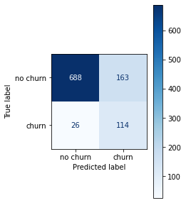

```python
# TRAINING SET
from mixed_naive_bayes import MixedNB

BayesClassifier = MixedNB(categorical_features=[1,2])
BayesClassifier.fit(x_trainb, y_trainb)
y_pred = BayesClassifier.predict(x_test)

cm = confusion_matrix(y_test, y_pred)
labels = ['no churn', 'churn']
cm_display = ConfusionMatrixDisplay(cm, display_labels=labels)

pos_class = 1

accuracy = accuracy_score(y_test, y_pred)
recall = recall_score(y_test, y_pred, pos_label=pos_class)
precision = precision_score(y_test, y_pred, pos_label=pos_class)
f1score = f1_score(y_test, y_pred, pos_label=pos_class)
print("")
print("")
print("Scores for the testing set:")
print('Accuracy score:', np.round(accuracy, 3))
print('Recall score for the positive class:', np.round(recall, 3))
print('Precision score for the positive class:', np.round(precision, 3))
print('F1 score for the positive class:', np.round(f1score, 3))
print("")
print('Confusion Matrix: ')
fig, ax = plt.subplots(figsize=(3,5))
cm_display.plot(ax=ax, cmap='Blues')
```

Comparing the scores obtained in both cases it is obvious the difference with the values, especially in the precision domain that dropped a lot. This could be related to the imbalanced test set or to the division and balancing of the dataset.

With such a contradiction between tests, but assuming the multiple tests of the cross-validation method have more weight, it can be concluded that this model, despite being easy to implement, can achieve good results, but still has room to improvement.

To improve the performance of the model, the threshold was adjusted to maximize the F1 score, as was done before.

```python
# OPTIMAL THRESHOLD
from mixed_naive_bayes import MixedNB

BayesClassifier = MixedNB(categorical_features=[1,2])
BayesClassifier.fit(x_trainb, y_trainb)

y_pred_1 = BayesClassifier.predict_proba(x_test)[:, 1]

f1_scores = [f1_score(y_test, y_pred_1 > t) for t in np.linspace(0, 1, 101)]
best_threshold = np.linspace(0, 1, 101)[np.argmax(f1_scores)]

print('Optimal threshold that maximizes the F1 score:', np.round(best_threshold,3))
```

```
Optimal threshold that maximizes the F1 score: 0.57
```

```python
from mixed_naive_bayes import MixedNB

BayesClassifier = MixedNB(categorical_features=[1,2])
BayesClassifier.fit(x_trainb, y_trainb)

proba = BayesClassifier.predict_proba(x_test)[:, 1]

pos_class = 1

y_pred = np.where(proba > 0.5, 1, 0)
print("Scores with the default threshold:")
accuracy = accuracy_score(y_test, y_pred)
recall = recall_score(y_test, y_pred, pos_label=pos_class)
precision = precision_score(y_test, y_pred, pos_label=pos_class)
f1score = f1_score(y_test, y_pred, pos_label=pos_class)
print('Accuracy score:', np.round(accuracy, 3))
print('Recall score for the positive class:', np.round(recall, 3))
print('Precision score for the positive class:', np.round(precision, 3))
print('F1 score for the positive class:', np.round(f1score, 3))

print("")

y_pred = np.where(proba > 0.57, 1, 0)
print("Scores with the optimal threshold:")
accuracy = accuracy_score(y_test, y_pred)
recall = recall_score(y_test, y_pred, pos_label=pos_class)
precision = precision_score(y_test, y_pred, pos_label=pos_class)
f1score = f1_score(y_test, y_pred, pos_label=pos_class)
print('Accuracy score:', np.round(accuracy, 3))
print('Recall score for the positive class:', np.round(recall, 3))
print('Precision score for the positive class:', np.round(precision, 3))
print('F1 score for the positive class:', np.round(f1score, 3))
```

```
Scores with the default threshold:
Accuracy score: 0.809
Recall score for the positive class: 0.814
Precision score for the positive class: 0.412
F1 score for the positive class: 0.547

Scores with the optimal threshold:
Accuracy score: 0.857
Recall score for the positive class: 0.779
Precision score for the positive class: 0.495
F1 score for the positive class: 0.606
```

The optimal threshold does increase some scores, but overall they did not change much.

Reference: https://towardsdatascience.com/introduction-to-na%C3%AFve-bayes-classifier-fa59e3e24aaf

#### 4.1.4 Decision Trees

```python
from sklearn.tree import DecisionTreeClassifier
clf = DecisionTreeClassifier(random_state=0)
clf.fit(x_trainb, y_trainb)
```

```
DecisionTreeClassifier(random_state=0)
```

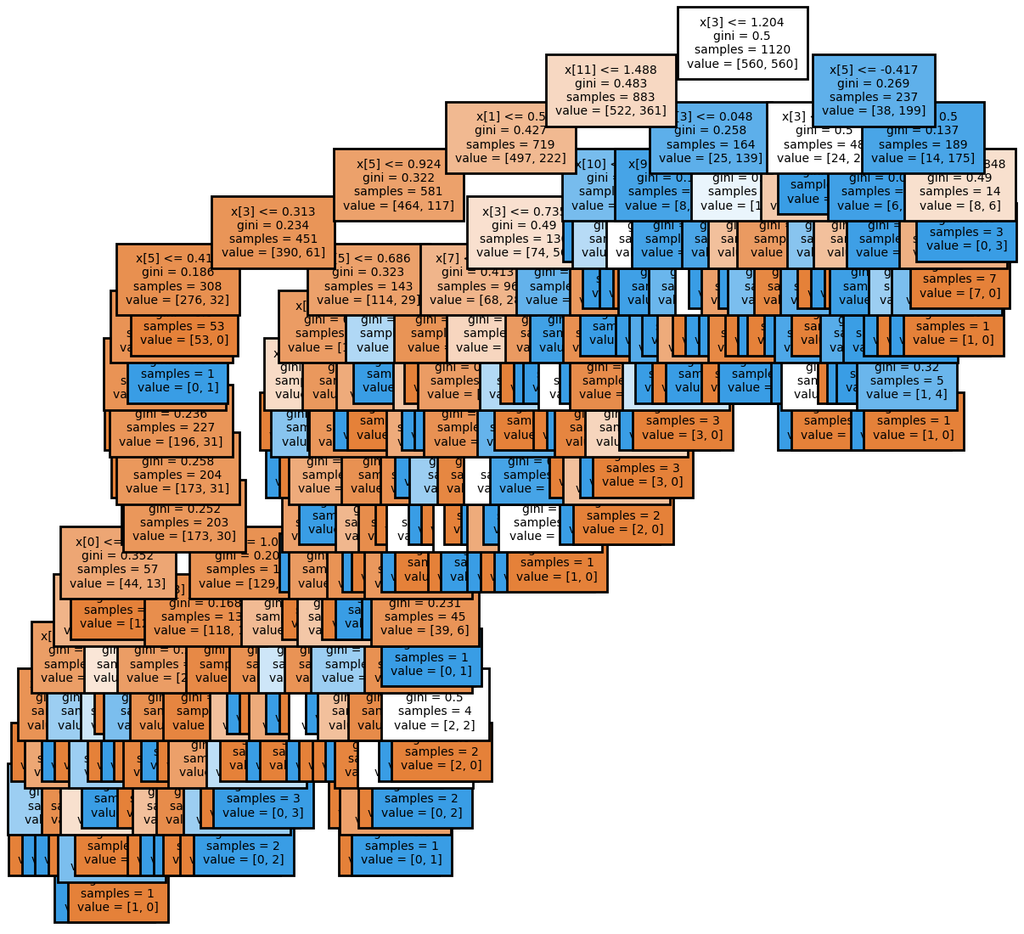

```python
from sklearn import tree
from matplotlib import pyplot as plt

def plottree(clf):
    plt.subplots(nrows = 1,ncols = 1,figsize = (7,7), dpi=200)
    tree.plot_tree(clf, fontsize=5, filled=True)
    plt.show()

plottree(clf)
```

The image above shows the Decision Tree for this problem, and it is very clear to see that it has an overfitting problem. In order to overcome this problem we need to to: Pre-Prune and Post-Prone. In the first stage, the goal is to find the optimal parameters for the max_depth, min_samples_leaf and min_samples_split.

```python
from sklearn.model_selection import GridSearchCV
param_grid = {'criterion':["gini","entropy"],
'max_depth': [2, 3, 4, 5],
'min_samples_leaf': [5,10, 20, 30],
'min_samples_split': [5,10,20, 30, 40]}
```

```python
grid_search = GridSearchCV(clf, param_grid, cv=5)
grid_search.fit(x_trainb, y_trainb)
print("Best hyperparameters: ", grid_search.best_params_)
```

```
Best hyperparameters:  {'criterion': 'entropy', 'max_depth': 5, 'min_samples_leaf': 10, 'min_samples_split': 5}
```

The second stage is to prune the branches of decision tree using Cost Complexity Pruning technique(CCP)

```python
path = clf.cost_complexity_pruning_path(x_train, y_train)
alphas, impurities = path.ccp_alphas, path.impurities
param_grid = {'ccp_alpha': alphas}

grid_search = GridSearchCV(clf, param_grid, cv=5)
grid_search.fit(x_trainb, y_trainb)

best_alpha = grid_search.best_params_['ccp_alpha']
print(best_alpha)
```

```
0.00394708825342628
```

```python
dt_modelb = DecisionTreeClassifier(random_state=0, ccp_alpha=0.0039, max_depth=5, min_samples_leaf=10,min_samples_split=5)
dt_modelb.fit(x_trainb,y_trainb)
```

```
DecisionTreeClassifier(ccp_alpha=0.0039, max_depth=5, min_samples_leaf=10,
                       min_samples_split=5, random_state=0)
```

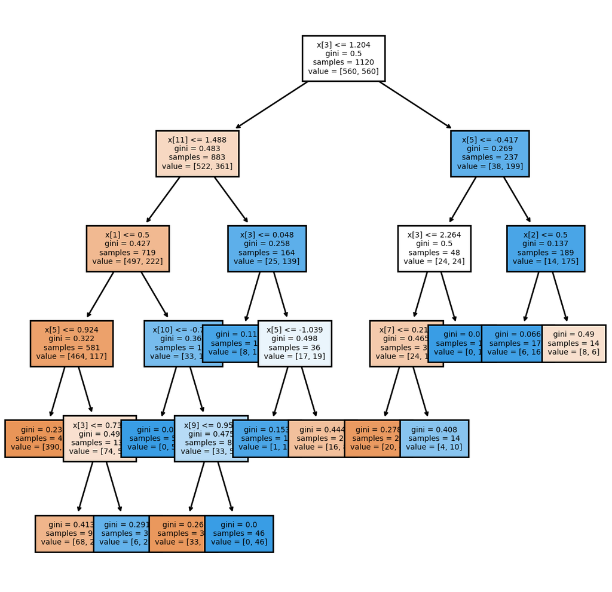

```python
from sklearn import tree
from matplotlib import pyplot as plt

def plottree(dt_modelb):
    plt.subplots(nrows = 1,ncols = 1,figsize = (7,7), dpi=200)
    tree.plot_tree(dt_modelb, fontsize=5, filled=True)
    plt.show()

plottree(dt_modelb)
```

```python
#Cross-Validation
from sklearn.model_selection import cross_validate

scoring = ['accuracy', 'recall', 'precision', 'f1']
scores = cross_validate(dt_modelb, x_trainb, y_trainb, cv=5, scoring=scoring)

print("Average Scores and Standard Deviation:")
for name in scoring:
	score_values = scores['test_' + name][2:]
	score_mean = np.mean(score_values)
	score_std = np.std(score_values)
	print("%0.3f %s with a standard deviation of %0.3f" % (score_mean, name, score_std))
```

```
Average Scores and Standard Deviation:
0.832 accuracy with a standard deviation of 0.027
0.756 recall with a standard deviation of 0.034
0.892 precision with a standard deviation of 0.033
0.818 f1 with a standard deviation of 0.030
```

```
Scores for the testing set:
Accuracy score: 0.925
Recall score for the positive class: 0.771
Precision score for the positive class: 0.72
F1 score for the positive class: 0.745

Confusion Matrix:
```

```
<sklearn.metrics._plot.confusion_matrix.ConfusionMatrixDisplay at 0x7fccd2336610>
```

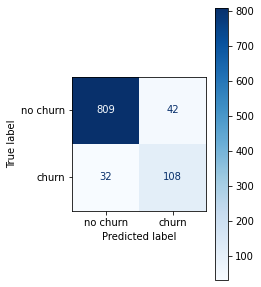

```python
# TRAINING SET
y_pred = dt_modelb.predict(x_test)

cm = confusion_matrix(y_test, y_pred)
labels = ['no churn', 'churn']
cm_display = ConfusionMatrixDisplay(cm, display_labels=labels)

pos_class = 1

accuracy = accuracy_score(y_test, y_pred)
recall = recall_score(y_test, y_pred, pos_label=pos_class)
precision = precision_score(y_test, y_pred, pos_label=pos_class)
f1score = f1_score(y_test, y_pred, pos_label=pos_class)
print("")
print("")
print("Scores for the testing set:")
print('Accuracy score:', np.round(accuracy, 3))
print('Recall score for the positive class:', np.round(recall, 3))
print('Precision score for the positive class:', np.round(precision, 3))
print('F1 score for the positive class:', np.round(f1score, 3))
print("")
print('Confusion Matrix: ')
fig, ax = plt.subplots(figsize=(3,5))
cm_display.plot(ax=ax, cmap='Blues')
```

```python
# OPTIMAL THRESHOLD
y_pred_1 = dt_modelb.predict_proba(x_test)[:, 1]

f1_scores = [f1_score(y_test, y_pred_1 > t) for t in np.linspace(0, 1, 101)]
best_threshold = np.linspace(0, 1, 101)[np.argmax(f1_scores)]

print('Optimal threshold that maximizes the F1 score:', np.round(best_threshold,3))
```

```
Optimal threshold that maximizes the F1 score: 0.92
```

```python
dt_modelb = DecisionTreeClassifier(random_state=0, ccp_alpha=0.0039, max_depth=5, min_samples_leaf=10,min_samples_split=5)
dt_modelb.fit(x_trainb,y_trainb)

proba =dt_modelb.predict_proba(x_test)[:, 1]

pos_class = 1

y_pred = np.where(proba > 0.5, 1, 0)
print("Scores with the default threshold:")
accuracy = accuracy_score(y_test, y_pred)
recall = recall_score(y_test, y_pred, pos_label=pos_class)
precision = precision_score(y_test, y_pred, pos_label=pos_class)
f1score = f1_score(y_test, y_pred, pos_label=pos_class)
print('Accuracy score:', np.round(accuracy, 3))
print('Recall score for the positive class:', np.round(recall, 3))
print('Precision score for the positive class:', np.round(precision, 3))
print('F1 score for the positive class:', np.round(f1score, 3))

print("")

y_pred = np.where(proba > 0.92, 1, 0)
print("Scores with the optimal threshold:")
accuracy = accuracy_score(y_test, y_pred)
recall = recall_score(y_test, y_pred, pos_label=pos_class)
precision = precision_score(y_test, y_pred, pos_label=pos_class)
f1score = f1_score(y_test, y_pred, pos_label=pos_class)
print('Accuracy score:', np.round(accuracy, 3))
print('Recall score for the positive class:', np.round(recall, 3))
print('Precision score for the positive class:', np.round(precision, 3))
print('F1 score for the positive class:', np.round(f1score, 3))
```

```
Scores with the default threshold:
Accuracy score: 0.925
Recall score for the positive class: 0.771
Precision score for the positive class: 0.72
F1 score for the positive class: 0.745

Scores with the optimal threshold:
Accuracy score: 0.934
Recall score for the positive class: 0.707
Precision score for the positive class: 0.805
F1 score for the positive class: 0.753
```

Reference: https://medium.com/@ompramod9921/decision-trees-8e2391f93fa7

#### 4.1.5 Ensembles

In order to find the best Ensemble method, we are going to perform a corss-validation, and chose the method that performs better

#### Random Forests

```python
from sklearn.ensemble import RandomForestClassifier
rf = RandomForestClassifier()
rf.fit(x_trainb, y_trainb)
```

```
RandomForestClassifier()
```

```python
from scipy.stats import randint
from sklearn.model_selection import RandomizedSearchCV
param_dist = {'n_estimators': randint(50,500),
              'max_depth': randint(1,20)}

rf = RandomForestClassifier()
rand_search = RandomizedSearchCV(rf,
                                 param_distributions = param_dist,
                                 n_iter=5,
                                 cv=5)
rand_search.fit(x_trainb, y_trainb)
```

```
RandomizedSearchCV(cv=5, estimator=RandomForestClassifier(), n_iter=5,
                   param_distributions={'max_depth': <scipy.stats._distn_infrastructure.rv_discrete_frozen object at 0x7fcce251d820>,
                                        'n_estimators': <scipy.stats._distn_infrastructure.rv_discrete_frozen object at 0x7fcc90086ca0>})
```

```python
best_rf = rand_search.best_estimator_
print('Best hyperparameters:',  rand_search.best_params_)
```

```
Best hyperparameters: {'max_depth': 11, 'n_estimators': 326}
```

```python
acc_rf=np.mean(cross_val_score(RandomForestClassifier(n_estimators=326,max_depth=11),x_trainb,y_trainb,cv=5))
print("acc_rf =",acc_rf)
```

```
acc_rf = 0.8482142857142858
```

References: https://medium.com/@ompramod9921/random-forests-32be04c8bf76 https://www.datacamp.com/tutorial/random-forests-classifier-python

#### Bagging

```python
from sklearn.ensemble import BaggingClassifier
acc_bag=np.mean(cross_val_score(BaggingClassifier(n_estimators=50),x_trainb,y_trainb,cv=5))
print("acc_bag =",acc_bag)
```

```
acc_bag = 0.8526785714285714
```

#### AdaBoost

```python
from sklearn.ensemble import AdaBoostClassifier
acc_ada=np.mean(cross_val_score(AdaBoostClassifier(n_estimators=50),x_trainb,y_trainb,cv=5))
print("acc_ada =",acc_ada)
```

```
acc_ada = 0.7803571428571429
```

#### Grandient Boosting

```python
from sklearn.ensemble import GradientBoostingClassifier
acc_gb=np.mean(cross_val_score(GradientBoostingClassifier(n_estimators=50),x_trainb,y_trainb,cv=5))
print("acc_gb =",acc_gb)
```

```
acc_gb = 0.8544642857142858
```

#### Xgboost

```python
import xgboost as xgb
```

```python
from xgboost import XGBClassifier

acc_xgb=np.mean(cross_val_score(XGBClassifier(n_estimators=50),x_trainb,y_trainb,cv=5))

print("acc_xgb =",acc_xgb)
```

```
acc_xgb = 0.8580357142857142
```

#### Optimize the Best Model: Xgboost

```python
#Cross-Validation
xgb=XGBClassifier(n_estimators=50)
scoring = ['accuracy', 'recall', 'precision', 'f1']
scores = cross_validate(xgb, x_trainb, y_trainb, cv=5, scoring=scoring)

print("Average Scores and Standard Deviation:")
for name in scoring:
	score_values = scores['test_' + name][2:]
	score_mean = np.mean(score_values)
	score_std = np.std(score_values)
	print("%0.3f %s with a standard deviation of %0.3f" % (score_mean, name, score_std))
```

```
Average Scores and Standard Deviation:
0.863 accuracy with a standard deviation of 0.026
0.821 recall with a standard deviation of 0.025
0.896 precision with a standard deviation of 0.031
0.857 f1 with a standard deviation of 0.027
```

```
Scores for the testing set:
Accuracy score: 0.903
Recall score for the positive class: 0.8
Precision score for the positive class: 0.622
F1 score for the positive class: 0.7

Confusion Matrix:
```

```
<sklearn.metrics._plot.confusion_matrix.ConfusionMatrixDisplay at 0x7fccc0c02820>
```

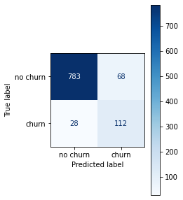

```python
# TRAINING SET
xgb=XGBClassifier(n_estimators=50)
xgb.fit(x_trainb, y_trainb)
y_pred = xgb.predict(x_test)

cm = confusion_matrix(y_test, y_pred)
labels = ['no churn', 'churn']
cm_display = ConfusionMatrixDisplay(cm, display_labels=labels)

pos_class = 1

accuracy = accuracy_score(y_test, y_pred)
recall = recall_score(y_test, y_pred, pos_label=pos_class)
precision = precision_score(y_test, y_pred, pos_label=pos_class)
f1score = f1_score(y_test, y_pred, pos_label=pos_class)
print("")
print("")
print("Scores for the testing set:")
print('Accuracy score:', np.round(accuracy, 3))
print('Recall score for the positive class:', np.round(recall, 3))
print('Precision score for the positive class:', np.round(precision, 3))
print('F1 score for the positive class:', np.round(f1score, 3))
print("")
print('Confusion Matrix: ')
fig, ax = plt.subplots(figsize=(3,5))
cm_display.plot(ax=ax, cmap='Blues')
```

```python
# OPTIMAL THRESHOLD
y_pred_1 = xgb.predict_proba(x_test)[:, 1]

f1_scores = [f1_score(y_test, y_pred_1 > t) for t in np.linspace(0, 1, 101)]
best_threshold = np.linspace(0, 1, 101)[np.argmax(f1_scores)]

print('Optimal threshold that maximizes the F1 score:', np.round(best_threshold,3))
```

```
Optimal threshold that maximizes the F1 score: 0.91
```

```python
xgb=XGBClassifier(n_estimators=50)
xgb.fit(x_trainb, y_trainb)

proba =xgb.predict_proba(x_test)[:, 1]

pos_class = 1

y_pred = np.where(proba > 0.5, 1, 0)
print("Scores with the default threshold:")
accuracy = accuracy_score(y_test, y_pred)
recall = recall_score(y_test, y_pred, pos_label=pos_class)
precision = precision_score(y_test, y_pred, pos_label=pos_class)
f1score = f1_score(y_test, y_pred, pos_label=pos_class)
print('Accuracy score:', np.round(accuracy, 3))
print('Recall score for the positive class:', np.round(recall, 3))
print('Precision score for the positive class:', np.round(precision, 3))
print('F1 score for the positive class:', np.round(f1score, 3))

print("")

y_pred = np.where(proba > 0.91, 1, 0)
print("Scores with the optimal threshold:")
accuracy = accuracy_score(y_test, y_pred)
recall = recall_score(y_test, y_pred, pos_label=pos_class)
precision = precision_score(y_test, y_pred, pos_label=pos_class)
f1score = f1_score(y_test, y_pred, pos_label=pos_class)
print('Accuracy score:', np.round(accuracy, 3))
print('Recall score for the positive class:', np.round(recall, 3))
print('Precision score for the positive class:', np.round(precision, 3))
print('F1 score for the positive class:', np.round(f1score, 3))
```

```
Scores with the default threshold:
Accuracy score: 0.903
Recall score for the positive class: 0.8
Precision score for the positive class: 0.622
F1 score for the positive class: 0.7

Scores with the optimal threshold:
Accuracy score: 0.947
Recall score for the positive class: 0.693
Precision score for the positive class: 0.907
F1 score for the positive class: 0.785
```

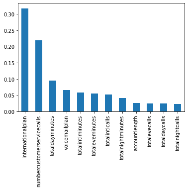

```python
feature_importances = pd.Series(xgb.feature_importances_, index=x_trainb.columns).sort_values(ascending=False)
feature_importances.plot.bar();
```

In this graph presents the features and their respective importance to the model. In this model, having an international Plan has more weight to predict the churn, and the Total Night Calls has the least importance.

#### 4.1.6 Support Vector Machines

The model SVC is a class that performs binary (or multi-class) classification using support vector machines. The default values of the model SVC in scikit-learn are as follows: **C** = 1.0, **kernel** = ‘rbf’, **degree** = 3, **gamma** = ‘scale’, **coef0** = 0.0, **shrinking** = True, **probability** = False, **tol** = 0.001, **cache_size** = 200, **class_weight** = None, **verbose** = False, **max_iter** = -1, **decision_function_shape** = ‘ovr’, **random_state** = None. The parameter **class_weight**='balanced' was employed in this section.

As before, cross-validation was used first, as illustrated below, to find the best parameters. After conducting several experiments, the parameters kernel='rbf', C=1, gamma=0.1 were found to be optimal. For the remaining parameters, the default values were used during the experiments.

```python
def SVC_balanced_CV(x, y, kernel='rbf', C=1, gamma=0.1):

    model = SVC(kernel=kernel, C=C, gamma=gamma, random_state=42, class_weight='balanced')

    scoring = ['accuracy', 'recall', 'precision', 'f1']

    scores = cross_validate(model, x_trainb, y_trainb, cv=5, scoring=scoring)

    print("Average Scores and Standard Deviation:")

    for name in scoring:
      score_values = scores['test_' + name]
      score_mean = np.mean(score_values)
      score_std = np.std(score_values)
      print("%0.3f %s with a standard deviation of %0.3f" % (score_mean, name, score_std))

SVC_balanced_CV(x, y, kernel='rbf', C=1, gamma=0.1)
```

```
Average Scores and Standard Deviation:
0.827 accuracy with a standard deviation of 0.021
0.811 recall with a standard deviation of 0.034
0.839 precision with a standard deviation of 0.027
0.824 f1 with a standard deviation of 0.021
```

The scores achieved using cross-validation indicate that the model has a good performance, as the mean scores are high and the standard deviations are low. None of the standard deviations exceed 10% of the mean scores, which means that the model is stable and consistent across different folds.

Below, the scores for the testing set are presented, using the optimal parameters of the SVC model and using x_test and y_test to make predictions and evaluate the model.

```
Scores for the testing set:
Accuracy score: 0.821
Recall score for the positive class: 0.814
Precision score for the positive class: 0.43
F1 score for the positive class: 0.563

AUPRC & AUROC:
Area under the precision-recall curve: 0.672
Area under the ROC curve: 0.882

Confusion Matrix:
```

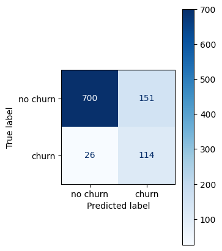

```python
def SVC_balanced(x, y, kernel='rbf', C=1, gamma=0.1):

    model = SVC(kernel=kernel, C=C,gamma=gamma,random_state=42,class_weight='balanced',probability=True)
    model.fit(x_trainb, y_trainb)

    y_pred=model.predict(x_test)

    cm = confusion_matrix(y_test, y_pred)
    labels = ['no churn', 'churn']
    cm_display = ConfusionMatrixDisplay(cm, display_labels=labels)

    pos_class = 1 # positive class

    accuracy = accuracy_score(y_test, y_pred)
    recall = recall_score(y_test, y_pred, pos_label=pos_class)
    precision = precision_score(y_test, y_pred, pos_label=pos_class)
    f1score = f1_score(y_test, y_pred, pos_label=pos_class)
    print("Scores for the testing set:")
    print('Accuracy score:', np.round(accuracy, 3))
    print('Recall score for the positive class:', np.round(recall, 3))
    print('Precision score for the positive class:', np.round(precision, 3))
    print('F1 score for the positive class:', np.round(f1score, 3))

    y_pred_1 = model.predict_proba(x_test)[:, 1]
    precision, recall, _ = precision_recall_curve(y_test, y_pred_1)
    fpr, tpr, _ = roc_curve(y_test, y_pred_1)
    print("")
    print("AUPRC & AUROC:")
    print('Area under the precision-recall curve:', np.round(auc(recall, precision),3))
    print('Area under the ROC curve:', np.round(auc(fpr, tpr),3))
    print("")
    print('Confusion Matrix: ')
    fig, ax = plt.subplots(figsize=(3,5))
    cm_display.plot(ax=ax, cmap='Blues')

SVC_balanced(x, y, kernel='rbf', C=1, gamma=0.1)
```

Comparing the scores obtained in the training set with cross-validation and the testing set, we can see a discrepancy, especially in the precision and F1 score. This is due to the imbalanced class distribution in the testing set, as discussed earlier.

Based on these results, the SVC model has a high recall and a low precision for the positive class, which means that it tends to label more cases as positive than they actually are. Moreover, the F1 score is considerably lower than the accuracy.

The model also has a high area under the ROC curve, which means that it can discriminate well between the positive and negative classes. However, the area under the precision-recall curve is relatively low, reinforcing that the model has a poor precision-recall trade-off.

To improve the performance of the SVC model, the threshold was adjusted to optimize the F1 score for the positive class in the testing set. The SVC model uses a decision function to assign a score to each input, and then compares the score to a threshold to determine the predicted class. The default threshold is zero, meaning that any input with a positive score is predicted as the positive class, and any input with a negative score is predicted as the negative class. The threshold of zero is based on the assumption that the decision function is centered around zero, and that the classes are balanced. To determine the optimal threshold value, the probability estimates were obtained using the predict_proba method, as shown in the code below. The decision_function method was also tested, but it yielded a similar output. Therefore, it was not included in this report. [referencia: https://stackoverflow.com/questions/58545711/how-to-set-a-value-for-a-specific-threshold-in-svc-model-and-generate-a-confusio, https://scikit-learn.org/stable/modules/generated/sklearn.svm.SVC.html.]

```python
def SVC_balanced_withthreshold(x, y, kernel='rbf', C=1, gamma=0.1):

    model = SVC(kernel=kernel, C=C,gamma=gamma,random_state=42,class_weight='balanced', probability=True)
    model.fit(x_trainb, y_trainb)

    y_pred_1 = model.predict_proba(x_test)[:, 1]

    f1_scores = [f1_score(y_test, y_pred_1 > t) for t in np.linspace(0, 1, 101)]
    best_threshold = np.linspace(0, 1, 101)[np.argmax(f1_scores)]
    print("Optimal threshold that maximizes the F1 score:",np.round(best_threshold,3))

    def predict_with_threshold(threshold=best_threshold):
        y_pred = (y_pred_1 > threshold)

        pos_class = 1

        accuracy = accuracy_score(y_test, y_pred)
        recall = recall_score(y_test, y_pred, pos_label=pos_class)
        precision = precision_score(y_test, y_pred, pos_label=pos_class)
        f1score = f1_score(y_test, y_pred, pos_label=pos_class)

        print('Accuracy score:', np.round(accuracy, 3))
        print('Recall score for the positive class:', np.round(recall, 3))
        print('Precision score for the positive class:', np.round(precision, 3))
        print('F1 score for the positive class:', np.round(f1score, 3))

    print("")
    print("Scores with the optimal threshold:")
    predict_with_threshold()

SVC_balanced_withthreshold(x, y, kernel='rbf', C=1, gamma=0.1)
```

```
Optimal threshold that maximizes the F1 score: 0.75

Scores with the optimal threshold:
Accuracy score: 0.902
Recall score for the positive class: 0.657
Precision score for the positive class: 0.652
F1 score for the positive class: 0.655
```

Based on the outputs, it seems that the SVC model performs better with the optimal threshold obtained in the predict_proba method then with the default threshold of zero for the decision function. The optimal threshold obtained achieves a higher accuracy, precision, and F1 score for the positive class, while the default threshold of zero for the decision function has a higher recall for the positive class. This means that the default threshold is more sensitive to the positive class, but also more prone to false positives. The optimal threshold obtained is more balanced and accurate in predicting both classes.

Reference: https://scikit-learn.org/stable/supervised_learning.html

#### 4.1.7 Neural Network Classifier

The Neural Network model performs binary (or multi-class) classification using **Multi-layer Perceptron** algorithm that trains using Backpropagation.

Cross-validation was used first, as illustrated below, to find the best parameters. After conducting several experiments, the parameters alpha=1e-2, max_iter=1000 with 2 hidden layers of size 100 were found to be around the best. This process requires tuning a number of hyperparameters such as the number of hidden neurons, layers, and iterations for maximum optimization that was not extensively executed.

```python
# CROSS-VALIDATION
from sklearn.neural_network import MLPClassifier

NNClassifier = MLPClassifier(solver='lbfgs', alpha=1e-2, hidden_layer_sizes=(100, 100), random_state=42, max_iter=1000)

scoring = ['accuracy', 'recall', 'precision', 'f1']
scores = cross_validate(NNClassifier, x_trainb, y_trainb, cv=5, scoring=scoring)

print("Average Scores and Standard Deviation:")
for name in scoring:
	score_values = scores['test_' + name]
	score_mean = np.mean(score_values)
	score_std = np.std(score_values)
	print("%0.3f %s with a standard deviation of %0.3f" % (score_mean, name, score_std))
```

```
Average Scores and Standard Deviation:
0.793 accuracy with a standard deviation of 0.022
0.791 recall with a standard deviation of 0.034
0.795 precision with a standard deviation of 0.029
0.792 f1 with a standard deviation of 0.022
```

The scores achieved show that the model has a good performance with all parameters rounding the 0.8 score and low standard deviation. This model appears stable and consistent across all diferent folds.

Below, the scores for the testing set are presented, using the optimal parameters of the model and using x_test and y_test to make predictions and evaluate the model.

```
Scores for the testing set:
Accuracy score: 0.786
Recall score for the positive class: 0.779
Precision score for the positive class: 0.376
F1 score for the positive class: 0.507
Confusion Matrix:
```

```
<sklearn.metrics._plot.confusion_matrix.ConfusionMatrixDisplay at 0x20eed55e850>
```

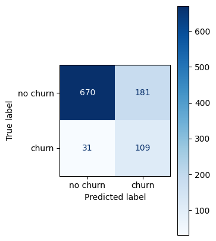

```python
# TRAINING TEST

from sklearn.neural_network import MLPClassifier

NNClassifier = MLPClassifier(solver='lbfgs', alpha=1e-2, hidden_layer_sizes=(100, 100), random_state=42, max_iter=1000)
NNClassifier.fit(x_trainb, y_trainb)
y_pred = NNClassifier.predict(x_test)

cm = confusion_matrix(y_test, y_pred)
labels = ['no churn', 'churn']
cm_display = ConfusionMatrixDisplay(cm, display_labels=labels)

pos_class = 1

accuracy = accuracy_score(y_test, y_pred)
recall = recall_score(y_test, y_pred, pos_label=pos_class)
precision = precision_score(y_test, y_pred, pos_label=pos_class)
f1score = f1_score(y_test, y_pred, pos_label=pos_class)
print("Scores for the testing set:")
print('Accuracy score:', np.round(accuracy, 3))
print('Recall score for the positive class:', np.round(recall, 3))
print('Precision score for the positive class:', np.round(precision, 3))
print('F1 score for the positive class:', np.round(f1score, 3))

print('Confusion Matrix: ')
fig, ax = plt.subplots(figsize=(3,5))
cm_display.plot(ax=ax, cmap='Blues')
```

Comparing the scores obtained in both cases there is a big discrepancy, especialy on the precision parameter. This due to imbalanced data or the division sets.

To improve even more the model, the threshold was adjusted to optimize the f1 score

```python
#Finding best threshold

from sklearn.neural_network import MLPClassifier

NNClassifier = MLPClassifier(solver='lbfgs', alpha=1e-2, hidden_layer_sizes=(100, 100), random_state=42, max_iter=100)
NNClassifier.fit(x_trainb, y_trainb)

y_pred_1 = NNClassifier.predict_proba(x_test)[:, 1]

f1_scores = [f1_score(y_test, y_pred_1 > t) for t in np.linspace(0, 1, 101)]
best_threshold = np.linspace(0, 1, 101)[np.argmax(f1_scores)]
print("Optimal threshold that maximizes the F1 score:",np.round(best_threshold,3))
```

```
Optimal threshold that maximizes the F1 score: 0.99
```

```python
# COMPARE

from sklearn.neural_network import MLPClassifier

NNClassifier = MLPClassifier(solver='lbfgs', alpha=1e-2, hidden_layer_sizes=(100, 100), random_state=42, max_iter=100)
NNClassifier.fit(x_trainb, y_trainb)

proba = NNClassifier.predict_proba(x_test)[:, 1]

pos_class = 1

y_pred = np.where(proba > 0.5, 1, 0)
print("Scores with the default threshold:")
accuracy = accuracy_score(y_test, y_pred)
recall = recall_score(y_test, y_pred, pos_label=pos_class)
precision = precision_score(y_test, y_pred, pos_label=pos_class)
f1score = f1_score(y_test, y_pred, pos_label=pos_class)
print('Accuracy score:', np.round(accuracy, 3))
print('Recall score for the positive class:', np.round(recall, 3))
print('Precision score for the positive class:', np.round(precision, 3))
print('F1 score for the positive class:', np.round(f1score, 3))

print("")

y_pred = np.where(proba > 0.99, 1, 0)
print("Scores with the optimal threshold:")
accuracy = accuracy_score(y_test, y_pred)
recall = recall_score(y_test, y_pred, pos_label=pos_class)
precision = precision_score(y_test, y_pred, pos_label=pos_class)
f1score = f1_score(y_test, y_pred, pos_label=pos_class)
print('Accuracy score:', np.round(accuracy, 3))
print('Recall score for the positive class:', np.round(recall, 3))
print('Precision score for the positive class:', np.round(precision, 3))
print('F1 score for the positive class:', np.round(f1score, 3))
```

```
Scores with the default threshold:
Accuracy score: 0.786
Recall score for the positive class: 0.779
Precision score for the positive class: 0.376
F1 score for the positive class: 0.507

Scores with the optimal threshold:
Accuracy score: 0.85
Recall score for the positive class: 0.721
Precision score for the positive class: 0.479
F1 score for the positive class: 0.575
```

As usual, the overall values got slightly better.

Reference: https://scikit-learn.org/stable/modules/neural_networks_supervised.html

### 4.2 Non-balanced Data

#### 4.2.1 Logistic Regression

In section 4.1.1, it was presented the default values for the logistic regression in scikit-learn.

After conducting several experiments with cross-validation, the parameters C=0.2, penalty='l2', and solver='liblinear' were found to be optimal. For the remaining parameters, the default values were used during the experiments.

```python
def LogReg_CV(x, y, C=0.2, penalty='l2',solver='liblinear'):

    LogReg = LogisticRegression(C=C, penalty=penalty, solver=solver, class_weight=None, dual=False, fit_intercept=True,
                                intercept_scaling=1, max_iter=100, multi_class='ovr', n_jobs=1,
                                tol=0.0001)

    scoring = ['accuracy', 'recall', 'precision', 'f1']

    scores = cross_validate(LogReg, x_train, y_train, cv=5, scoring=scoring)

    print("Average Scores and Standard Deviation:")

    for name in scoring:
      score_values = scores['test_' + name]
      score_mean = np.mean(score_values)
      score_std = np.std(score_values)
      print("%0.3f %s with a standard deviation of %0.3f" % (score_mean, name, score_std))

LogReg_CV(x, y, C=0.2, penalty='l2',solver='liblinear')
```

```
Average Scores and Standard Deviation:
0.867 accuracy with a standard deviation of 0.007
0.184 recall with a standard deviation of 0.023
0.599 precision with a standard deviation of 0.084
0.281 f1 with a standard deviation of 0.034
```

The precision score has a high standard deviation of 0.084, which indicates that the model is unstable and sensitive to the random selection of the data. Additionally, the model has a high accuracy, but a low recall and a low F1 score for the positive class. This means that the model is good at avoiding false positive errors, but poor at avoiding false negative errors.

Below, the Coefficients, pseudo R square, and scores for the testing set are presented, using the optimal parameters of the logistic regression and using x_test and y_test to make predictions and evaluate the model.

```
                            Coefficients (betas)
accountlength                              0.093
internationalplan                          1.820
voicemailplan                             -0.931
totaldayminutes                            0.697
totaldaycalls                              0.051
totaleveminutes                            0.357
totalevecalls                             -0.020
totalnightminutes                          0.186
totalnightcalls                           -0.072
totalintlminutes                           0.222
totalintlcalls                            -0.158
numbercustomerservicecalls                 0.653
Model intercept: [-2.185]
Pseudo R square: 0.21


Scores for the testing set:
Accuracy score: 0.864
Recall score for the positive class: 0.157
Precision score for the positive class: 0.564
F1 score for the positive class: 0.246

AUPRC & AUROC:
Area under the precision-recall curve: 0.461
Area under the ROC curve: 0.818

Confusion Matrix:
```

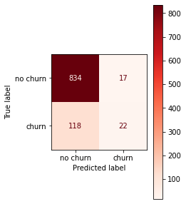

```python
def LogReg(x, y, C=0.2, penalty='l2',solver='liblinear'):

    LogReg = LogisticRegression(C=C, penalty=penalty, solver=solver, class_weight=None, dual=False, fit_intercept=True,
                                intercept_scaling=1, max_iter=100, multi_class='ovr', n_jobs=1,
                                tol=0.0001)

    LogReg.fit(x_train, y_train)
    y_pred = LogReg.predict(x_test)

    coef_df = pd.DataFrame(np.round(LogReg.coef_, 3), columns=x.columns)
    coef_df_transposed = coef_df.transpose()
    coef_df_transposed.columns = ['Coefficients (betas)']

    print(coef_df_transposed)
    print("Model intercept:", np.round(LogReg.intercept_, 3))

    nll_model = log_loss(y_test, LogReg.predict_proba(x_test))
    nll_null = log_loss(y_test, np.repeat(y_train.mean(), len(y_test)))
    pseudo_r2 = 1 - (nll_model / nll_null)
    print('Pseudo R square:', np.round(pseudo_r2, 3))

    cm = confusion_matrix(y_test, y_pred)
    labels = ['no churn', 'churn']
    cm_display = ConfusionMatrixDisplay(cm, display_labels=labels)

    pos_class = 1

    accuracy = accuracy_score(y_test, y_pred)
    recall = recall_score(y_test, y_pred, pos_label=pos_class)
    precision = precision_score(y_test, y_pred, pos_label=pos_class)
    f1score = f1_score(y_test, y_pred, pos_label=pos_class)
    print("")
    print("")
    print("Scores for the testing set:")
    print('Accuracy score:', np.round(accuracy, 3))
    print('Recall score for the positive class:', np.round(recall, 3))
    print('Precision score for the positive class:', np.round(precision, 3))
    print('F1 score for the positive class:', np.round(f1score, 3))

    y_pred_1 = LogReg.predict_proba(x_test)[:, 1]
    precision, recall, _ = precision_recall_curve(y_test, y_pred_1)
    fpr, tpr, _ = roc_curve(y_test, y_pred_1)
    print("")
    print("AUPRC & AUROC:")
    print('Area under the precision-recall curve:', np.round(auc(recall, precision),3))
    print('Area under the ROC curve:', np.round(auc(fpr, tpr),3))
    print("")
    print('Confusion Matrix: ')
    fig, ax = plt.subplots(figsize=(3,5))
    cm_display.plot(ax=ax, cmap='Reds')

LogReg(x, y, C=0.2, penalty='l2',solver='liblinear')
```

The cross-validated training set and the testing set yield comparable scores, owing to the similar distributions of the sets.

Additionally, to improve the performance of the logistic regression model, the threshold was adjusted to optimize the F1 score for the positive class in the testing set, as shown below.

```python
def optimalt_LogReg(x, y, C=0.2, penalty='l2',solver='liblinear'):

    LogReg = LogisticRegression(C=C, penalty=penalty, solver=solver, class_weight=None, dual=False, fit_intercept=True,
                                intercept_scaling=1, max_iter=100, multi_class='ovr', n_jobs=1,
                                tol=0.0001)

    LogReg.fit(x_train, y_train)

    y_pred_1 = LogReg.predict_proba(x_test)[:, 1]

    f1_scores = [f1_score(y_test, y_pred_1 > t) for t in np.linspace(0, 1, 101)]
    best_threshold = np.linspace(0, 1, 101)[np.argmax(f1_scores)]

    print('Optimal threshold that maximizes the F1 score:', np.round(best_threshold,3))

optimalt_LogReg(x, y, C=0.2, penalty='l2',solver='liblinear')
```

```
Optimal threshold that maximizes the F1 score: 0.2
```

```python
def LogReg_withthreshold(x, y, C=0.2, threshold= 0.2, penalty='l2',solver='liblinear'):

    LogReg = LogisticRegression(C=C, penalty=penalty, solver=solver, class_weight=None, dual=False, fit_intercept=True,
                                intercept_scaling=1, max_iter=100, multi_class='ovr', n_jobs=1,
                                tol=0.0001)

    LogReg.fit(x_train, y_train)

    proba = LogReg.predict_proba(x_test)[:, 1]
    y_pred = np.where(proba > threshold, 1, 0)

    pos_class = 1

    accuracy = accuracy_score(y_test, y_pred)
    recall = recall_score(y_test, y_pred, pos_label=pos_class)
    precision = precision_score(y_test, y_pred, pos_label=pos_class)
    f1score = f1_score(y_test, y_pred, pos_label=pos_class)
    print('Accuracy score:', np.round(accuracy, 3))
    print('Recall score for the positive class:', np.round(recall, 3))
    print('Precision score for the positive class:', np.round(precision, 3))
    print('F1 score for the positive class:', np.round(f1score, 3))

print("Scores with the default threshold (0.5):")
LogReg_withthreshold(x, y, C=0.2, threshold= 0.5, penalty='l2',solver='liblinear')
print("")
print("Scores with the optimal threshold (0.2):")
LogReg_withthreshold(x, y, C=0.2, threshold= 0.2, penalty='l2',solver='liblinear')
```

```
Scores with the default threshold (0.5):
Accuracy score: 0.864
Recall score for the positive class: 0.157
Precision score for the positive class: 0.564
F1 score for the positive class: 0.246

Scores with the optimal threshold (0.2):
Accuracy score: 0.811
Recall score for the positive class: 0.643
Precision score for the positive class: 0.396
F1 score for the positive class: 0.49
```

By lowering the threshold, the model becomes more sensitive to the positive class, and increases the recall score significantly. Additionally, as expected, the f1 score is better with the optimal threshold, but remains low.

Reference: https://scikit-learn.org/stable/supervised_learning.html

#### 4.2.2 KNN

```python
from sklearn import neighbors
from sklearn.model_selection import GridSearchCV
params = {'n_neighbors':[2,3,4,5,6,7,8,9,10,11]}
knn = neighbors.KNeighborsRegressor()
knn_model = GridSearchCV(knn, params, cv=5)
knn_model.fit(x_train,y_train)
knn_model.best_params_
```

```
{'n_neighbors': 11}
```

```python
#Cross Validation
KNNClassifier = KNeighborsClassifier(n_neighbors=11)
scoring = ['accuracy', 'recall', 'precision', 'f1']
scores = cross_validate(KNNClassifier, x_train, y_train, cv=5, scoring=scoring)

print("Average Scores and Standard Deviation:")
for name in scoring:
    score_values = scores['test_' + name][2:]
    score_mean = np.mean(score_values)
    score_std = np.std(score_values)
    print("%0.3f %s with a standard deviation of %0.3f" % (score_mean, name, score_std))
```

```
Average Scores and Standard Deviation:
0.876 accuracy with a standard deviation of 0.005
0.152 recall with a standard deviation of 0.033
0.833 precision with a standard deviation of 0.052
0.256 f1 with a standard deviation of 0.048
```

```
Scores for the testing set:
Accuracy score: 0.886
Recall score for the positive class: 0.2
Precision score for the positive class: 0.966
F1 score for the positive class: 0.331

Confusion Matrix:
```

```
<sklearn.metrics._plot.confusion_matrix.ConfusionMatrixDisplay at 0x7fd0d0d75730>
```

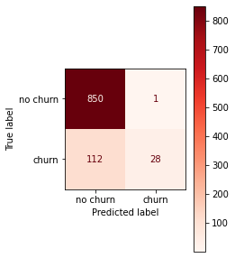

```python
# TRAINING SET
KNNClassifier.fit(x_train, y_train)
y_pred = KNNClassifier.predict(x_test)

cm = confusion_matrix(y_test, y_pred)
labels = ['no churn', 'churn']
cm_display = ConfusionMatrixDisplay(cm, display_labels=labels)

pos_class = 1

accuracy = accuracy_score(y_test, y_pred)
recall = recall_score(y_test, y_pred, pos_label=pos_class)
precision = precision_score(y_test, y_pred, pos_label=pos_class)
f1score = f1_score(y_test, y_pred, pos_label=pos_class)
print("")
print("")
print("Scores for the testing set:")
print('Accuracy score:', np.round(accuracy, 3))
print('Recall score for the positive class:', np.round(recall, 3))
print('Precision score for the positive class:', np.round(precision, 3))
print('F1 score for the positive class:', np.round(f1score, 3))
print("")
print('Confusion Matrix: ')
fig, ax = plt.subplots(figsize=(3,5))
cm_display.plot(ax=ax, cmap='Reds')
```

To improve the performance of the model, the threshold was adjujsted to maximize the F1 score, as was done before.

```python
# OPTIMAL THRESHOLD
KNNClassifier = KNeighborsClassifier(n_neighbors=11)
KNNClassifier.fit(x_train, y_train)

y_pred_1 = KNNClassifier.predict_proba(x_test)[:, 1]

f1_scores = [f1_score(y_test, y_pred_1 > t) for t in np.linspace(0, 1, 101)]
best_threshold = np.linspace(0, 1, 101)[np.argmax(f1_scores)]

print('Optimal threshold that maximizes the F1 score:', np.round(best_threshold,3))
```

[output not shown]

```python
KNNClassifier = KNeighborsClassifier(n_neighbors=11)
KNNClassifier.fit(x_train, y_train)

proba =KNNClassifier.predict_proba(x_test)[:, 1]

pos_class = 1

y_pred = np.where(proba > 0.5, 1, 0)
print("Scores with the default threshold:")
accuracy = accuracy_score(y_test, y_pred)
recall = recall_score(y_test, y_pred, pos_label=pos_class)
precision = precision_score(y_test, y_pred, pos_label=pos_class)
f1score = f1_score(y_test, y_pred, pos_label=pos_class)
print('Accuracy score:', np.round(accuracy, 3))
print('Recall score for the positive class:', np.round(recall, 3))
print('Precision score for the positive class:', np.round(precision, 3))
print('F1 score for the positive class:', np.round(f1score, 3))

print("")

y_pred = np.where(proba > 0.23, 1, 0)
print("Scores with the optimal threshold:")
accuracy = accuracy_score(y_test, y_pred)
recall = recall_score(y_test, y_pred, pos_label=pos_class)
precision = precision_score(y_test, y_pred, pos_label=pos_class)
f1score = f1_score(y_test, y_pred, pos_label=pos_class)
print('Accuracy score:', np.round(accuracy, 3))
print('Recall score for the positive class:', np.round(recall, 3))
print('Precision score for the positive class:', np.round(precision, 3))
print('F1 score for the positive class:', np.round(f1score, 3))
```

```
Scores with the default threshold:
Accuracy score: 0.886
Recall score for the positive class: 0.2
Precision score for the positive class: 0.966
F1 score for the positive class: 0.331

Scores with the optimal threshold:
Accuracy score: 0.876
Recall score for the positive class: 0.571
Precision score for the positive class: 0.559
F1 score for the positive class: 0.565
```

#### 4.2.3 Bayesian Classifier

Everything done in chapter 4.1.3 will be mirrored here with the expetion of the train set.

```python
from sklearn.preprocessing import LabelEncoder

label_encoder = LabelEncoder()
x_train["internationalplan"] = label_encoder.fit_transform(x_train["internationalplan"])
x_train["voicemailplan"] = label_encoder.fit_transform(x_train["voicemailplan"])
```

```python
# CROSS VALIDATION
from mixed_naive_bayes import MixedNB

BayesClassifier = MixedNB(categorical_features=[1,2])

scoring = ['accuracy', 'recall', 'precision', 'f1']
scores = cross_validate(BayesClassifier, x_train, y_train, cv=5, scoring=scoring)

print("Average Scores and Standard Deviation:")
for name in scoring:
	score_values = scores['test_' + name]
	score_mean = np.mean(score_values)
	score_std = np.std(score_values)
	print("%0.3f %s with a standard deviation of %0.3f" % (score_mean, name, score_std))
```

```
Average Scores and Standard Deviation:
0.875 accuracy with a standard deviation of 0.013
0.248 recall with a standard deviation of 0.044
0.649 precision with a standard deviation of 0.076
0.358 f1 with a standard deviation of 0.055
```

This time the model got higher values of accuracy but with very low values of f1. This could be caused because the model, despite doing better with more inputs to train, is not balanced leading to low recall and precision values.

```
Scores for the testing set:
Accuracy score: 0.87
Recall score for the positive class: 0.243
Precision score for the positive class: 0.596
F1 score for the positive class: 0.345

Confusion Matrix:
```

```
<sklearn.metrics._plot.confusion_matrix.ConfusionMatrixDisplay at 0x7fccc0a3cdf0>
```

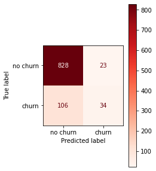

```python
#TRAINING SET
from mixed_naive_bayes import MixedNB

BayesClassifier = MixedNB(categorical_features=[1,2])
BayesClassifier.fit(x_train, y_train)
y_pred = BayesClassifier.predict(x_test)

cm = confusion_matrix(y_test, y_pred)
labels = ['no churn', 'churn']
cm_display = ConfusionMatrixDisplay(cm, display_labels=labels)

pos_class = 1

accuracy = accuracy_score(y_test, y_pred)
recall = recall_score(y_test, y_pred, pos_label=pos_class)
precision = precision_score(y_test, y_pred, pos_label=pos_class)
f1score = f1_score(y_test, y_pred, pos_label=pos_class)
print("")
print("")
print("Scores for the testing set:")
print('Accuracy score:', np.round(accuracy, 3))
print('Recall score for the positive class:', np.round(recall, 3))
print('Precision score for the positive class:', np.round(precision, 3))
print('F1 score for the positive class:', np.round(f1score, 3))
print("")
print('Confusion Matrix: ')
fig, ax = plt.subplots(figsize=(3,5))
cm_display.plot(ax=ax, cmap='Reds')
```

The same conclusions from before can be taken here, when comparing to the balanced view of the problem.

```python
#Finding optimal threshold
from mixed_naive_bayes import MixedNB

BayesClassifier = MixedNB(categorical_features=[1,2])
BayesClassifier.fit(x_train, y_train)

y_pred_1 = BayesClassifier.predict_proba(x_test)[:, 1]

f1_scores = [f1_score(y_test, y_pred_1 > t) for t in np.linspace(0, 1, 101)]
best_threshold = np.linspace(0, 1, 101)[np.argmax(f1_scores)]

print('Optimal threshold that maximizes the F1 score:', np.round(best_threshold,3))
```

```
Optimal threshold that maximizes the F1 score: 0.18
```

```python
from mixed_naive_bayes import MixedNB

BayesClassifier = MixedNB(categorical_features=[1,2])
BayesClassifier.fit(x_train, y_train)

proba = BayesClassifier.predict_proba(x_test)[:, 1]

pos_class = 1

y_pred = np.where(proba > 0.5, 1, 0)
print("Scores with the default threshold:")
accuracy = accuracy_score(y_test, y_pred)
recall = recall_score(y_test, y_pred, pos_label=pos_class)
precision = precision_score(y_test, y_pred, pos_label=pos_class)
f1score = f1_score(y_test, y_pred, pos_label=pos_class)
print('Accuracy score:', np.round(accuracy, 3))
print('Recall score for the positive class:', np.round(recall, 3))
print('Precision score for the positive class:', np.round(precision, 3))
print('F1 score for the positive class:', np.round(f1score, 3))

print("")

y_pred = np.where(proba > 0.18, 1, 0)
print("Scores with the optimal threshold:")
accuracy = accuracy_score(y_test, y_pred)
recall = recall_score(y_test, y_pred, pos_label=pos_class)
precision = precision_score(y_test, y_pred, pos_label=pos_class)
f1score = f1_score(y_test, y_pred, pos_label=pos_class)
print('Accuracy score:', np.round(accuracy, 3))
print('Recall score for the positive class:', np.round(recall, 3))
print('Precision score for the positive class:', np.round(precision, 3))
print('F1 score for the positive class:', np.round(f1score, 3))
```

```
Scores with the default threshold:
Accuracy score: 0.87
Recall score for the positive class: 0.243
Precision score for the positive class: 0.596
F1 score for the positive class: 0.345

Scores with the optimal threshold:
Accuracy score: 0.869
Recall score for the positive class: 0.771
Precision score for the positive class: 0.524
F1 score for the positive class: 0.624
```

This time, finding an optimal threshold increased a lot the results without repercussions to the accuracy, leading to an overall very good model, contrary to what the conclusion up to this point were demonstrating.

Reference: https://towardsdatascience.com/introduction-to-na%C3%AFve-bayes-classifier-fa59e3e24aaf

#### 4.2.4 Decision Trees

```python
clf = DecisionTreeClassifier(random_state=0)
clf.fit(x_train, y_train)
```

```
DecisionTreeClassifier(random_state=0)
```

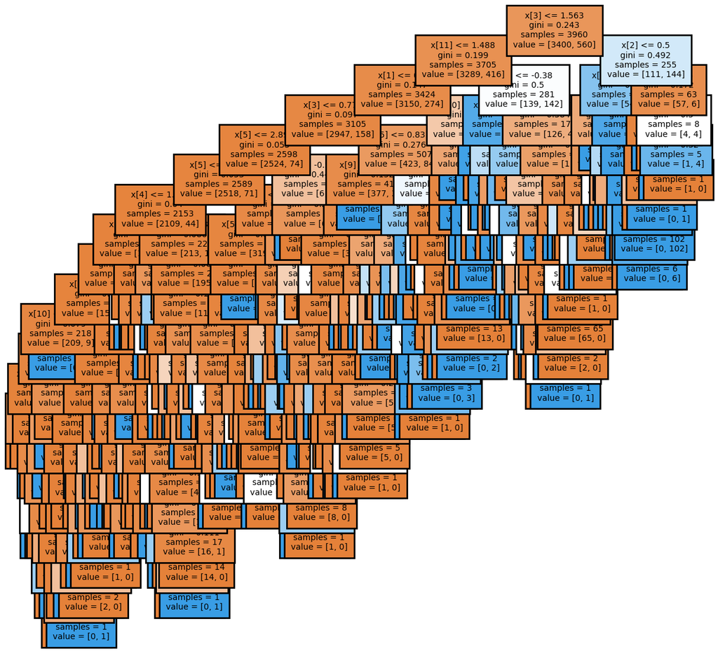

```python
from sklearn import tree
from matplotlib import pyplot as plt

def plottree(clf):
    plt.subplots(nrows = 1,ncols = 1,figsize = (7,7), dpi=200)
    tree.plot_tree(clf, fontsize=5, filled=True)
    plt.show()

plottree(clf)
```

The image above shows the Decision Tree for this problem, and it is very clear to see that it has an overfitting problem. In order to overcome this problem we need to to: Pre-Prune and Post-Prone. In the first stage, the goal is to find the optimal parameters for the max_depth, min_samples_leaf and min_samples_split.

```python
from sklearn.model_selection import GridSearchCV

param_grid = {'criterion':["gini","entropy"],
'max_depth': [2, 3, 4, 5],
'min_samples_leaf': [5,10, 20, 30],
'min_samples_split': [5,10,20, 30, 40]}
```

```python
grid_search = GridSearchCV(clf, param_grid, cv=5)
grid_search.fit(x_train, y_train)
print("Best hyperparameters: ", grid_search.best_params_)
```

```
Best hyperparameters:  {'criterion': 'entropy', 'max_depth': 5, 'min_samples_leaf': 10, 'min_samples_split': 5}
```

The second stage is to prune the branches of decision tree using Cost Complexity Pruning technique(CCP)

```python
path = clf.cost_complexity_pruning_path(x_train, y_train)
alphas, impurities = path.ccp_alphas, path.impurities
param_grid = {'ccp_alpha': alphas}

grid_search = GridSearchCV(clf, param_grid, cv=5)
grid_search.fit(x_train, y_train)

best_alpha = grid_search.best_params_['ccp_alpha']
print(best_alpha)
```

```
0.0013608680637666143
```

```python
dt_model = DecisionTreeClassifier(random_state=0, ccp_alpha=0.001, max_depth=5, min_samples_leaf=10,min_samples_split=5)
dt_model.fit(x_train,y_train)
```

```
DecisionTreeClassifier(ccp_alpha=0.001, max_depth=5, min_samples_leaf=10,
                       min_samples_split=5, random_state=0)
```

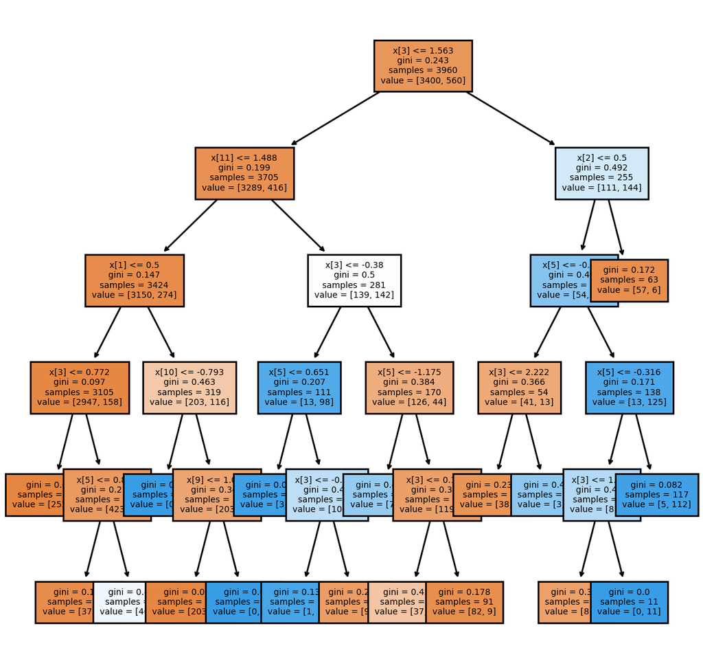

```python
from sklearn import tree
from matplotlib import pyplot as plt

def plottree(dt_model):
    plt.subplots(nrows = 1,ncols = 1,figsize = (7,7), dpi=200)
    tree.plot_tree(dt_model, fontsize=5, filled=True)
    plt.show()

plottree(dt_model)
```

```python
#Cross-Validation
from sklearn.model_selection import cross_validate

scoring = ['accuracy', 'recall', 'precision', 'f1']
scores = cross_validate(dt_model, x_train, y_train, cv=5, scoring=scoring)

print("Average Scores and Standard Deviation:")
for name in scoring:
	score_values = scores['test_' + name][2:]
	score_mean = np.mean(score_values)
	score_std = np.std(score_values)
	print("%0.3f %s with a standard deviation of %0.3f" % (score_mean, name, score_std))
```

```
Average Scores and Standard Deviation:
0.936 accuracy with a standard deviation of 0.010
0.670 recall with a standard deviation of 0.013
0.846 precision with a standard deviation of 0.064
0.747 f1 with a standard deviation of 0.032
```

```
Scores for the testing set:
Accuracy score: 0.933
Recall score for the positive class: 0.679
Precision score for the positive class: 0.819
F1 score for the positive class: 0.742

Confusion Matrix:
```

```
<sklearn.metrics._plot.confusion_matrix.ConfusionMatrixDisplay at 0x7fcce2877ee0>
```

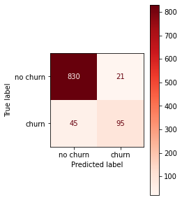

```python
# TRAINING SET
y_pred = dt_model.predict(x_test)

cm = confusion_matrix(y_test, y_pred)
labels = ['no churn', 'churn']
cm_display = ConfusionMatrixDisplay(cm, display_labels=labels)

pos_class = 1

accuracy = accuracy_score(y_test, y_pred)
recall = recall_score(y_test, y_pred, pos_label=pos_class)
precision = precision_score(y_test, y_pred, pos_label=pos_class)
f1score = f1_score(y_test, y_pred, pos_label=pos_class)
print("")
print("")
print("Scores for the testing set:")
print('Accuracy score:', np.round(accuracy, 3))
print('Recall score for the positive class:', np.round(recall, 3))
print('Precision score for the positive class:', np.round(precision, 3))
print('F1 score for the positive class:', np.round(f1score, 3))
print("")
print('Confusion Matrix: ')
fig, ax = plt.subplots(figsize=(3,5))
cm_display.plot(ax=ax, cmap='Reds')
```

```python
# OPTIMAL THRESHOLD
y_pred_1 = dt_model.predict_proba(x_test)[:, 1]

f1_scores = [f1_score(y_test, y_pred_1 > t) for t in np.linspace(0, 1, 101)]
best_threshold = np.linspace(0, 1, 101)[np.argmax(f1_scores)]

print('Optimal threshold that maximizes the F1 score:', np.round(best_threshold,3))
```

```
Optimal threshold that maximizes the F1 score: 0.19
```

```python
dt_model = DecisionTreeClassifier(random_state=0, ccp_alpha=0.001, max_depth=5, min_samples_leaf=10,min_samples_split=5)
dt_model.fit(x_train,y_train)

proba =dt_model.predict_proba(x_test)[:, 1]

pos_class = 1

y_pred = np.where(proba > 0.5, 1, 0)
print("Scores with the default threshold:")
accuracy = accuracy_score(y_test, y_pred)
recall = recall_score(y_test, y_pred, pos_label=pos_class)
precision = precision_score(y_test, y_pred, pos_label=pos_class)
f1score = f1_score(y_test, y_pred, pos_label=pos_class)
print('Accuracy score:', np.round(accuracy, 3))
print('Recall score for the positive class:', np.round(recall, 3))
print('Precision score for the positive class:', np.round(precision, 3))
print('F1 score for the positive class:', np.round(f1score, 3))

print("")

y_pred = np.where(proba > 0.19, 1, 0)
print("Scores with the optimal threshold:")
accuracy = accuracy_score(y_test, y_pred)
recall = recall_score(y_test, y_pred, pos_label=pos_class)
precision = precision_score(y_test, y_pred, pos_label=pos_class)
f1score = f1_score(y_test, y_pred, pos_label=pos_class)
print('Accuracy score:', np.round(accuracy, 3))
print('Recall score for the positive class:', np.round(recall, 3))
print('Precision score for the positive class:', np.round(precision, 3))
print('F1 score for the positive class:', np.round(f1score, 3))
```

```
Scores with the default threshold:
Accuracy score: 0.933
Recall score for the positive class: 0.679
Precision score for the positive class: 0.819
F1 score for the positive class: 0.742

Scores with the optimal threshold:
Accuracy score: 0.931
Recall score for the positive class: 0.743
Precision score for the positive class: 0.765
F1 score for the positive class: 0.754
```

Reference: https://medium.com/@ompramod9921/decision-trees-8e2391f93fa7

#### 4.2.5 Ensembles

#### Random Forests

```python
from sklearn.ensemble import RandomForestClassifier
rf = RandomForestClassifier()
rf.fit(x_train, y_train)
```

```
RandomForestClassifier()
```

```python
from scipy.stats import randint
from sklearn.model_selection import RandomizedSearchCV
param_dist = {'n_estimators': randint(50,500),
              'max_depth': randint(1,20)}

rf = RandomForestClassifier()
rand_search = RandomizedSearchCV(rf,
                                 param_distributions = param_dist,
                                 n_iter=5,
                                 cv=5)
rand_search.fit(x_train, y_train)
```

```
RandomizedSearchCV(cv=5, estimator=RandomForestClassifier(), n_iter=5,
                   param_distributions={'max_depth': <scipy.stats._distn_infrastructure.rv_discrete_frozen object at 0x7fcce2f92b80>,
                                        'n_estimators': <scipy.stats._distn_infrastructure.rv_discrete_frozen object at 0x7fcce2f924c0>})
```

```python
best_rf = rand_search.best_estimator_

print('Best hyperparameters:',  rand_search.best_params_)
```

```
Best hyperparameters: {'max_depth': 15, 'n_estimators': 265}
```

```python
acc_rf=np.mean(cross_val_score(RandomForestClassifier(n_estimators=265,max_depth=15),x_train,y_train,cv=5))
print("acc_rf =",acc_rf)
```

```
acc_rf = 0.9479797979797979
```

References: https://medium.com/@ompramod9921/random-forests-32be04c8bf76 https://www.datacamp.com/tutorial/random-forests-classifier-python

#### Bagging

```python
from sklearn.ensemble import BaggingClassifier
acc_bag=np.mean(cross_val_score(BaggingClassifier(n_estimators=50),x,y,cv=5))
print("acc_bag =",acc_bag)
```

```
acc_bag = 0.9486986922708416
```

#### AdaBoost

```python
from sklearn.ensemble import AdaBoostClassifier
acc_ada=np.mean(cross_val_score(AdaBoostClassifier(n_estimators=50),x,y,cv=5))
print("acc_ada =",acc_ada)
```

```
acc_ada = 0.883862642571018
```

#### Grandient Boosting

```python
from sklearn.ensemble import GradientBoostingClassifier
acc_gb=np.mean(cross_val_score(GradientBoostingClassifier(n_estimators=50),x,y,cv=5))
print("acc_gb =",acc_gb)
```

```
acc_gb = 0.9452649604011866
```

#### Xgboost

```python
import xgboost as xgb
```

```python
from xgboost import XGBClassifier
acc_xgb=np.mean(cross_val_score(XGBClassifier(n_estimators=50),x,y,cv=5))
print("acc_xgb =",acc_xgb)
```

```
acc_xgb = 0.9525356491249528
```

#### Optimize the Best Model: Xgboost

```python
#Cross-Validation
xgb=XGBClassifier(n_estimators=50)
scoring = ['accuracy', 'recall', 'precision', 'f1']
scores = cross_validate(xgb, x_train, y_train, cv=5, scoring=scoring)

print("Average Scores and Standard Deviation:")
for name in scoring:
	score_values = scores['test_' + name][2:]
	score_mean = np.mean(score_values)
	score_std = np.std(score_values)
	print("%0.3f %s with a standard deviation of %0.3f" % (score_mean, name, score_std))
```

```
Average Scores and Standard Deviation:
0.949 accuracy with a standard deviation of 0.005
0.723 recall with a standard deviation of 0.019
0.900 precision with a standard deviation of 0.023
0.802 f1 with a standard deviation of 0.019
```

```
Scores for the testing set:
Accuracy score: 0.955
Recall score for the positive class: 0.743
Precision score for the positive class: 0.92
F1 score for the positive class: 0.822

Confusion Matrix:
```

```
<sklearn.metrics._plot.confusion_matrix.ConfusionMatrixDisplay at 0x7fccd24c6040>
```

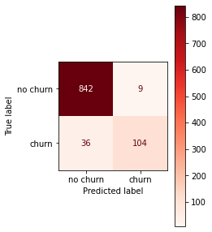

```python
# TRAINING SET
xgb=XGBClassifier(n_estimators=50)
xgb.fit(x_train, y_train)
y_pred = xgb.predict(x_test)

cm = confusion_matrix(y_test, y_pred)
labels = ['no churn', 'churn']
cm_display = ConfusionMatrixDisplay(cm, display_labels=labels)

pos_class = 1

accuracy = accuracy_score(y_test, y_pred)
recall = recall_score(y_test, y_pred, pos_label=pos_class)
precision = precision_score(y_test, y_pred, pos_label=pos_class)
f1score = f1_score(y_test, y_pred, pos_label=pos_class)
print("")
print("")
print("Scores for the testing set:")
print('Accuracy score:', np.round(accuracy, 3))
print('Recall score for the positive class:', np.round(recall, 3))
print('Precision score for the positive class:', np.round(precision, 3))
print('F1 score for the positive class:', np.round(f1score, 3))
print("")
print('Confusion Matrix: ')
fig, ax = plt.subplots(figsize=(3,5))
cm_display.plot(ax=ax, cmap='Reds')
```

```python
# OPTIMAL THRESHOLD
y_pred_1 = xgb.predict_proba(x_test)[:, 1]

f1_scores = [f1_score(y_test, y_pred_1 > t) for t in np.linspace(0, 1, 101)]
best_threshold = np.linspace(0, 1, 101)[np.argmax(f1_scores)]

print('Optimal threshold that maximizes the F1 score:', np.round(best_threshold,3))
```

```
Optimal threshold that maximizes the F1 score: 0.29
```

```python
xgb=XGBClassifier(n_estimators=50)
xgb.fit(x_train, y_train)

proba =xgb.predict_proba(x_test)[:, 1]

pos_class = 1

y_pred = np.where(proba > 0.5, 1, 0)
print("Scores with the default threshold:")
accuracy = accuracy_score(y_test, y_pred)
recall = recall_score(y_test, y_pred, pos_label=pos_class)
precision = precision_score(y_test, y_pred, pos_label=pos_class)
f1score = f1_score(y_test, y_pred, pos_label=pos_class)
print('Accuracy score:', np.round(accuracy, 3))
print('Recall score for the positive class:', np.round(recall, 3))
print('Precision score for the positive class:', np.round(precision, 3))
print('F1 score for the positive class:', np.round(f1score, 3))

print("")

y_pred = np.where(proba > 0.29, 1, 0)
print("Scores with the optimal threshold:")
accuracy = accuracy_score(y_test, y_pred)
recall = recall_score(y_test, y_pred, pos_label=pos_class)
precision = precision_score(y_test, y_pred, pos_label=pos_class)
f1score = f1_score(y_test, y_pred, pos_label=pos_class)
print('Accuracy score:', np.round(accuracy, 3))
print('Recall score for the positive class:', np.round(recall, 3))
print('Precision score for the positive class:', np.round(precision, 3))
print('F1 score for the positive class:', np.round(f1score, 3))
```

```
Scores with the default threshold:
Accuracy score: 0.955
Recall score for the positive class: 0.743
Precision score for the positive class: 0.92
F1 score for the positive class: 0.822

Scores with the optimal threshold:
Accuracy score: 0.956
Recall score for the positive class: 0.779
Precision score for the positive class: 0.893
F1 score for the positive class: 0.832
```

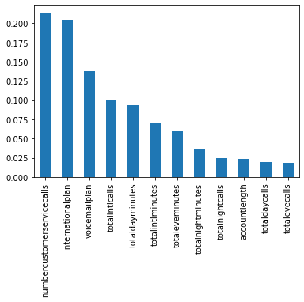

```python
feature_importances = pd.Series(xgb.feature_importances_, index=x_train.columns).sort_values(ascending=False)
feature_importances.plot.bar();
```

In this graph presents the features and their respective importance to the model. In this model, the Number of Custumer Service Calld has more weight to predict the churn, and the Total Evening Calls has the least importance.

#### 4.2.6 Support Vector Machines

In section 4.1.6, it was presented the default values for the SVC model in scikit-learn.

After conducting several experiments with cross-validation, the parameters kernel='rbf', C=10, gamma=0.1 were found to be optimal. For the remaining parameters, the default values were used during the experiments.

```python
def SVC_CV(x, y, kernel='rbf', C=10, gamma=0.1):

    model = SVC(kernel=kernel, C=C, gamma=gamma, random_state=42)

    scoring = ['accuracy', 'recall', 'precision', 'f1']

    scores = cross_validate(model, x_train, y_train, cv=5, scoring=scoring)

    print("Average Scores and Standard Deviation:")

    for name in scoring:
      score_values = scores['test_' + name]
      score_mean = np.mean(score_values)
      score_std = np.std(score_values)
      print("%0.3f %s with a standard deviation of %0.3f" % (score_mean, name, score_std))

SVC_CV(x, y, kernel='rbf', C=10, gamma=0.1)
```

```
Average Scores and Standard Deviation:
0.918 accuracy with a standard deviation of 0.007
0.596 recall with a standard deviation of 0.027
0.777 precision with a standard deviation of 0.053
0.674 f1 with a standard deviation of 0.025
```

Below, the scores for the testing set are presented, using the optimal parameters of the SVC model and using x_test and y_test to make predictions and evaluate the model.

```
Scores for the testing set:
Accuracy score: 0.916
Recall score for the positive class: 0.586
Precision score for the positive class: 0.766
F1 score for the positive class: 0.664

AUPRC & AUROC:
Area under the precision-recall curve: 0.746
Area under the ROC curve: 0.884

Confusion Matrix:
```

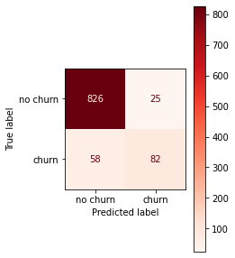

```python
def SVC_1(x, y, kernel='rbf', C=10, gamma=0.1):

    model = SVC(kernel=kernel, C=C,gamma=gamma,random_state=42,probability=True)
    model.fit(x_train, y_train)

    y_pred=model.predict(x_test)

    cm = confusion_matrix(y_test, y_pred)
    labels = ['no churn', 'churn']
    cm_display = ConfusionMatrixDisplay(cm, display_labels=labels)

    pos_class = 1

    accuracy = accuracy_score(y_test, y_pred)
    recall = recall_score(y_test, y_pred, pos_label=pos_class)
    precision = precision_score(y_test, y_pred, pos_label=pos_class)
    f1score = f1_score(y_test, y_pred, pos_label=pos_class)
    print("Scores for the testing set:")
    print('Accuracy score:', np.round(accuracy, 3))
    print('Recall score for the positive class:', np.round(recall, 3))
    print('Precision score for the positive class:', np.round(precision, 3))
    print('F1 score for the positive class:', np.round(f1score, 3))

    y_pred_1 = model.predict_proba(x_test)[:, 1]
    precision, recall, _ = precision_recall_curve(y_test, y_pred_1)
    fpr, tpr, _ = roc_curve(y_test, y_pred_1)
    print("")
    print("AUPRC & AUROC:")
    print('Area under the precision-recall curve:', np.round(auc(recall, precision),3))
    print('Area under the ROC curve:', np.round(auc(fpr, tpr),3))
    print("")
    print('Confusion Matrix: ')
    fig, ax = plt.subplots(figsize=(3,5))
    cm_display.plot(ax=ax, cmap='Reds')

SVC_1(x, y, kernel='rbf', C=10, gamma=0.1)
```

The cross-validated training set and the testing set yield comparable scores, owing to the similar distributions of the sets.

To improve the performance of the SVC model, the threshold was adjusted to optimize the F1 score for the positive class in the testing set. As done in the 4.1.6 section (with the balanced data), to determine the optimal threshold value, the probability estimates were obtained using the predict_proba method, as shown in the code below. The decision_function method was also tested, but it yielded a similar output. Therefore, it was not included in this report.

```python
def SVC_withthreshold(x, y, kernel='rbf', C=10, gamma=0.1):

    model = SVC(kernel=kernel, C=C,gamma=gamma,random_state=42,probability=True)
    model.fit(x_train, y_train)

    y_pred_1 = model.predict_proba(x_test)[:, 1]

    f1_scores = [f1_score(y_test, y_pred_1 > t) for t in np.linspace(0, 1, 101)]
    best_threshold = np.linspace(0, 1, 101)[np.argmax(f1_scores)]
    print("Optimal threshold that maximizes the F1 score:",np.round(best_threshold,3))

    def predict_with_threshold(threshold=best_threshold):
        y_pred = (y_pred_1 > threshold)

        pos_class = 1

        accuracy = accuracy_score(y_test, y_pred)
        recall = recall_score(y_test, y_pred, pos_label=pos_class)
        precision = precision_score(y_test, y_pred, pos_label=pos_class)
        f1score = f1_score(y_test, y_pred, pos_label=pos_class)

        print('Accuracy score:', np.round(accuracy, 3))
        print('Recall score for the positive class:', np.round(recall, 3))
        print('Precision score for the positive class:', np.round(precision, 3))
        print('F1 score for the positive class:', np.round(f1score, 3))

    print("")
    print("Scores with the optimal threshold:")
    predict_with_threshold()

SVC_withthreshold(x, y, kernel='rbf', C=10, gamma=0.1)
```

```
Optimal threshold that maximizes the F1 score: 0.28

Scores with the optimal threshold:
Accuracy score: 0.911
Recall score for the positive class: 0.707
Precision score for the positive class: 0.678
F1 score for the positive class: 0.692
```

The results show that using the optimal threshold, obtained with the predict_proba method, improves slightly the recall and the f1 score for the positive class, compared to the default threshold for the decision function.

Reference: https://scikit-learn.org/stable/supervised_learning.html

#### 4.2.7 Neural Network Classifier

Starting with cross-validation. The same parameters from 4.1.7 were used here.

```python
#Neural Network CROSS VAL
from sklearn.neural_network import MLPClassifier

NNClassifier = MLPClassifier(solver='lbfgs', alpha=1e-2, hidden_layer_sizes=(100, 100), random_state=42, max_iter=1000)

scoring = ['accuracy', 'recall', 'precision', 'f1']
scores = cross_validate(NNClassifier, x_train, y_train, cv=5, scoring=scoring)

print("Average Scores and Standard Deviation:")
for name in scoring:
	score_values = scores['test_' + name]
	score_mean = np.mean(score_values)
	score_std = np.std(score_values)
	print("%0.3f %s with a standard deviation of %0.3f" % (score_mean, name, score_std))
```

```
Average Scores and Standard Deviation:
0.922 accuracy with a standard deviation of 0.003
0.680 recall with a standard deviation of 0.026
0.747 precision with a standard deviation of 0.026
0.711 f1 with a standard deviation of 0.009
```

The scores show a remarkable value for the accuracy of the model. However, the non-balanced data lowers the recall and precisiion scores and therefore the f1 score.

```
Scores for the testing set:
Accuracy score: 0.921
Recall score for the positive class: 0.664
Precision score for the positive class: 0.75
F1 score for the positive class: 0.705
Confusion Matrix:
```

```
<sklearn.metrics._plot.confusion_matrix.ConfusionMatrixDisplay at 0x7fcce2729fa0>
```

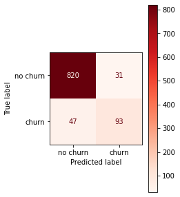

```python
#Neural Network TEST

from sklearn.neural_network import MLPClassifier

NNClassifier = MLPClassifier(solver='lbfgs', alpha=1e-2, hidden_layer_sizes=(100, 100), random_state=42, max_iter=100)
NNClassifier.fit(x_train, y_train)
y_pred = NNClassifier.predict(x_test)

cm = confusion_matrix(y_test, y_pred)
labels = ['no churn', 'churn']
cm_display = ConfusionMatrixDisplay(cm, display_labels=labels)

pos_class = 1

accuracy = accuracy_score(y_test, y_pred)
recall = recall_score(y_test, y_pred, pos_label=pos_class)
precision = precision_score(y_test, y_pred, pos_label=pos_class)
f1score = f1_score(y_test, y_pred, pos_label=pos_class)
print("Scores for the testing set:")
print('Accuracy score:', np.round(accuracy, 3))
print('Recall score for the positive class:', np.round(recall, 3))
print('Precision score for the positive class:', np.round(precision, 3))
print('F1 score for the positive class:', np.round(f1score, 3))

print('Confusion Matrix: ')
fig, ax = plt.subplots(figsize=(3,5))
cm_display.plot(ax=ax, cmap='Reds')
```

As seen in the confusion matrix, a huge part of the predictions were right and overall the model got good scores.

This can still be improved with with a better threshold.

```python
#Finding best threshold

from sklearn.neural_network import MLPClassifier

NNClassifier = MLPClassifier(solver='lbfgs', alpha=1e-2, hidden_layer_sizes=(100, 100), random_state=42, max_iter=100)
NNClassifier.fit(x_train, y_train)

y_pred_1 = NNClassifier.predict_proba(x_test)[:, 1]

f1_scores = [f1_score(y_test, y_pred_1 > t) for t in np.linspace(0, 1, 101)]
best_threshold = np.linspace(0, 1, 101)[np.argmax(f1_scores)]
print("Optimal threshold that maximizes the F1 score:",np.round(best_threshold,3))
```

[output not shown]

```python
#Compare

from sklearn.neural_network import MLPClassifier

NNClassifier = MLPClassifier(solver='lbfgs', alpha=1e-2, hidden_layer_sizes=(100, 100), random_state=42, max_iter=100)
NNClassifier.fit(x_train, y_train)

proba = NNClassifier.predict_proba(x_test)[:, 1]

pos_class = 1

y_pred = np.where(proba > 0.5, 1, 0)
print("Scores with the default threshold:")
accuracy = accuracy_score(y_test, y_pred)
recall = recall_score(y_test, y_pred, pos_label=pos_class)
precision = precision_score(y_test, y_pred, pos_label=pos_class)
f1score = f1_score(y_test, y_pred, pos_label=pos_class)
print('Accuracy score:', np.round(accuracy, 3))
print('Recall score for the positive class:', np.round(recall, 3))
print('Precision score for the positive class:', np.round(precision, 3))
print('F1 score for the positive class:', np.round(f1score, 3))

print("")

y_pred = np.where(proba > 0.99, 1, 0)
print("Scores with the optimal threshold:")
accuracy = accuracy_score(y_test, y_pred)
recall = recall_score(y_test, y_pred, pos_label=pos_class)
precision = precision_score(y_test, y_pred, pos_label=pos_class)
f1score = f1_score(y_test, y_pred, pos_label=pos_class)
print('Accuracy score:', np.round(accuracy, 3))
print('Recall score for the positive class:', np.round(recall, 3))
print('Precision score for the positive class:', np.round(precision, 3))
print('F1 score for the positive class:', np.round(f1score, 3))
```

```
Scores with the default threshold:
Accuracy score: 0.921
Recall score for the positive class: 0.664
Precision score for the positive class: 0.75
F1 score for the positive class: 0.705

Scores with the optimal threshold:
Accuracy score: 0.929
Recall score for the positive class: 0.629
Precision score for the positive class: 0.83
F1 score for the positive class: 0.715
```

This time though the threshold change did not affect significantly the scores.

The outputs once more show that the Neural Network Model has very good and very balanced results which means that it would be a very good model to try and optimize.

Reference: https://scikit-learn.org/stable/modules/neural_networks_supervised.html

## 5 | Main Conclusions

### What is the best model and the recommended data science procedure for the business?

When comparing balanced and unbalanced data, unbalanced data achieved higher accuracy for both sets (training and testing), while the balanced data achieved higher f1 scores for the training set after crossing validation. Regarding the optimization with the threshold, the f1 scores are quite similar. As previously discussed, the cross-validation discrepancies are probably attributable not only to the data balancing but also to the adverse effects of this balancing, which result in a significant reduction of the data by under sampling the original dataset. Under Sampling was selected after examining both Under and Over sampling methods and their common uses.

Regarding all the different methods, on the balanced side of the problem, the XGBoostb Ensemble and SVM achieved an overall good performance, with all the scores above 0.800 after cross-validation within the training set, with the first one having the higher f1 score (0.857). Before and after optimization with a threshold within the testing set, the models with higher f1 scores were the Decision Trees and the XGBoosting Ensemble, with a f1 score of 0.753 and 0.785, respectively after optimization (the remaining scores are all above 0.650 for these models).

On the unbalanced side of the problem, after cross-validation within the training set, the Decision Trees, XGBoosting Ensemble and NNetwork achieved the best scores (all scores above 0.650). The best f1 score was achieved once again by the XGBoosting Ensemble model (0.802). Similar results were achieved within the testing set, being the XGBoost Ensembles model the one with the best f1 score and a good performance overall (with all scores above 0.750).

### What can the business gain from these data science effort?

Looking only into the data science side of the problem, the business gains different working models, each one with its own best features, giving the company different possibilities to deploy based on their preferences. The chosen model for a given time does not have to be definitive and when the predictions start failing all models can be tuned again with new and more recent datasets since this report has built-in tunning functions for most models.

In general, after this initial step, the business would need deficient effort to maintain and optimize its activity in the future and with some adjustments, classification could go even further with some general classes:

- For clients with a predicted_proba > .75 = high risk of churning, we can design a “strong” retention strategy. Since we expect few false positives, we can afford to invest in these clients with higher confidence.
- Clients with predicted_proba between .5 and .75 = moderate risk of churning and “moderate” retention strategy.
- Clients with predicted_proba between .25 and .5 = low risk of churning and “weak” retention strategy.

Reference: https://towardsdatascience.com/a-framework-for-analyzing-churn-370d2283b75c

### What are the lessons learnt?

Even though the big image of data science revolves around modelling, evaluation and deployment, the first steps of CRISP-DM of Business Understanding, Data Understanding and Data Preparation are the ones that require most of the time and attention to progress further into the CRISP-DM cycle with ease.

This project shows that there is not a perfect model but a plethora of models that under certain circumstances can do a great job at modelling given problems under certain circumstances.

Despite the conclusions for the best model on the previous point, different business problems may require different models. For the same problem, different amounts of data can change the effectiveness of each model.

### What is the summary of the achieved results?

Achieving high accuracy values for the models with reasonably high values for the recall and F1 score is a great success for this project. Some models ended up having low overall scores most likely because they are not the best for this problem in particular, due to imbalanced data or assumptions that do not hold.

### Is there any particular characteristic of the data that makes the models difficult to classify?

While looking for the influence of each feature on the models, in both scenarios, the total calls for day, night and evening, and the customer account length had the lower impact on predicting the results. This could mean that these variables are not interesting to the problem, and add noise to the prediction since all models have false positives and false negatives.

### What model would be chosen to explain how the model is doing it's predictions to the colleagues of the marketing department? And what would be the most accurate?

To understand how these models are doing their predictions we can take a look at the Bayesian Classifier. Naive Bayes is a technique that takes all features of a given dataset, assumes independence between them, and calculates the probability of each feature applying to each class. After this is done for the training set each entity of the test set will multiply the probability corresponding to each feature and that translates into one of the classes, giving the final classification.

Looking at the results obtained from each model, in balanced data and non-balanced data, the model that achieved the highest accuracy was the XGBoost Ensemble method.